# 06_Final_Analysis

Edoardo Diana

2025-11-30

## Introduzione

Questo documento presenta l’analisi della Cora Citation network.

A tal scopo, essa viene svolta andando a rispondere a delle domande che guideranno l’analisi.

### Domande

- Network quick view

1 : Qual è il numero di paper in ogni categoria ?

2 : Qual è la distribuzione del numero di citazioni fatte dai paper ?

3 : Per ogni catgoria, quante sono le citazioni verso la stessa categoria ?

4.1 : Quali sono le top coppie di paper con più paper citati in comune ? (common successors) 4.2 : Quali sono le top coppie di paper con più paper citanti in comune ? (common predecessors)

- Centrality

5 : Analizza i top paper per PageRank e scopri se tale valore è principalmente causato da :

```
* numero di link che riceve
* centralità dei nodi da cui riceve i link
* quanto i nodi da cui si ricevono i link sono propensi a linkar altri nodi
```

6 : Analizza Authority ed Hub score per capire quali paper risultano maggiormente influenti.

7 : Identifica categorie potenti che non sono centrali e categorie centrali che non sono potenti.

8 : Visualizzare la rete tra categorie con la dimensione dei nodi proporzionale alla power e alla centralità, colore archi proporzionale al flusso di citazioni.

- Similarity ed eterogenity

9 : I paper con alta centralità tendono ad essere interdisciplinari ?

10 : I paper interdisciplinari (alto Rao da out-degree) sono più influenti (alto in-degree/PageRank) ?

11 : Quali categorie producono i paper più interdisciplinari ? E quali beneficiano di più dai ponti interdisciplinari?

- Group Analysis

12 : Identifica le comunità di paper e verifica se esse coincidono con le categorie scientifiche (ground truth). Se no, quale divisione in gruppi risulta esser più adatta alla rete ? Quella iniziale (categorie) o quella trovata (communities) ?

13 : Quali categorie sono più pure ? (una sola community o meno possibili)

- Global Analysis

14 : Studia i K-connected components e verifica se i gruppi con connettività più alta sono composti da soli paper di una stessa catgoria.

15 : Analizza gli SCC per verificare l’aciclicità della rete.

16 : Verifica lo Small-World Effect sul grafo non diretto.

17 : Verifica che la Assortativity by category sia molto alta (dato che ho tante citazioni intra-categoria)

18 : Verifica se l’elite delle pubblicazioni crea un “club” chiuso

## Carico le librerie

```r
library(igraph)
library(dplyr)
library(tidygraph)
library(ggrepel)
library(ggplot2)
library(ggraph)
library(Matrix)
library(corrplot)
library(tidyr)
library(knitr)
```

## Fase preliminare : lettura e filtraggio di Nodi ed Edges

Costruisco il grafo di citazioni Cora a partire dai file raw di nodi e archi

```r
# Percorsi dati
data_raw_dir <- "../data/raw"
cora_content_file <- file.path(data_raw_dir, "cora.content")
cora_cites_file <- file.path(data_raw_dir, "cora.cites")


# Lettura nodi
content_df <- read.table(cora_content_file, header = FALSE, stringsAsFactors = FALSE, fill = TRUE)
category_col <- ncol(content_df)

content_nodes <- data.frame(
  paper_id = content_df[, 1],
  category = content_df[, category_col],
  stringsAsFactors = FALSE
)

cat("Letti paper:", nrow(content_nodes), "\n")
```

```
## Letti paper: 2708
```

```r
cat("Categorie:", unique(content_nodes$category), "\n\n")
```

```
## Categorie: Neural_Networks Rule_Learning Reinforcement_Learning Probabilistic_Methods Theory Genetic_Algorithms Case_Based
```

```r
# Lettura edges
cites_df <- read.table(cora_cites_file, header = FALSE, stringsAsFactors = FALSE)
colnames(cites_df) <- c("paper_cited", "paper_citing")


edges <- cites_df %>%
  rename(from = paper_citing, to = paper_cited)

cat("Numero di archi (citazioni) trovate :", nrow(cites_df), "\n\n")
```

```
## Numero di archi (citazioni) trovate : 5429
```

```r
graph_igraph <- graph_from_data_frame(
  d = edges,
  vertices = content_nodes,
  directed = TRUE
)

graph <- as_tbl_graph(graph_igraph)
```

## Domanda 1 : Qual è il numero di paper in ogni categoria ?

```r
category_table <- content_nodes %>%
  group_by(category) %>%
  summarise(numero_paper = n()) %>%
  arrange(desc(numero_paper))

print(category_table)
```

```
## # A tibble: 7 × 2
##   category               numero_paper
##   <chr>                         <int>
## 1 Neural_Networks                 818
## 2 Probabilistic_Methods           426
## 3 Genetic_Algorithms              418
## 4 Theory                          351
## 5 Case_Based                      298
## 6 Reinforcement_Learning          217
## 7 Rule_Learning                   180
```

Vengono mostrati i numeri nella tabella sopra riportata.

## Domanda 2 : Qual è la distribuzione del numero di citazioni fatte dai paper ?

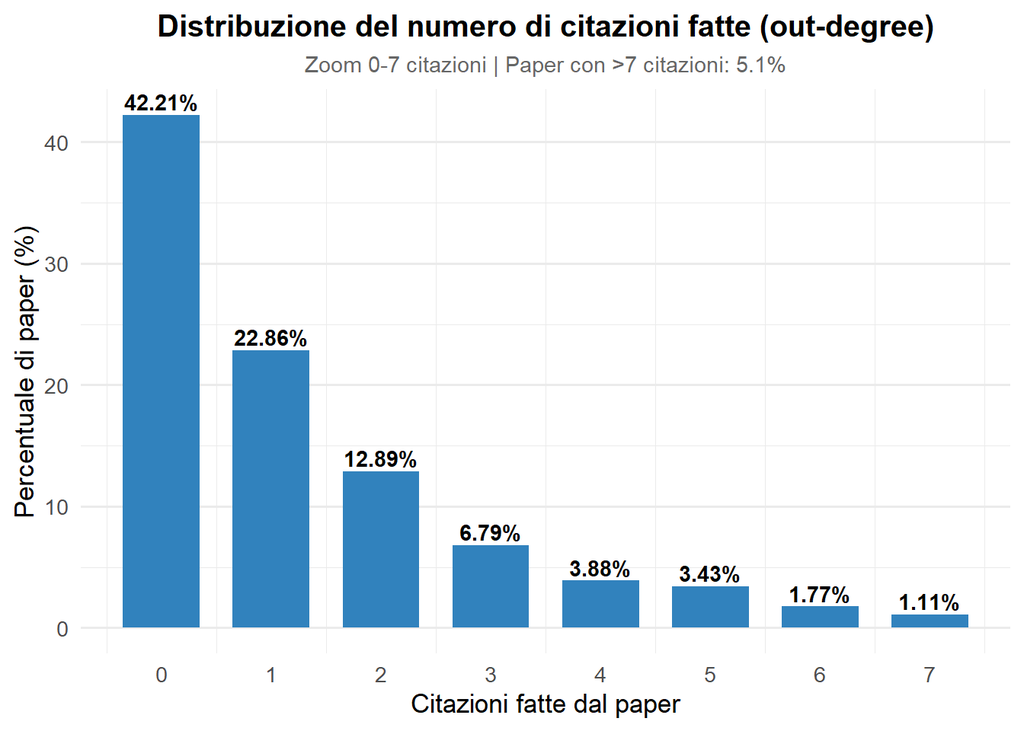

```r
out_deg <- degree(graph_igraph, mode = "out")

outdeg_table <- as.data.frame(table(out_deg))
colnames(outdeg_table) <- c("citazioni_fatte", "numero_paper")

# Percentuale di nodi con quel out-degree
outdeg_table$perc_nodi <- round(
  100 * outdeg_table$numero_paper / sum(outdeg_table$numero_paper),
  2
)


# Converto citazioni_fatte in numerico
outdeg_table$citazioni_fatte <- as.numeric(as.character(outdeg_table$citazioni_fatte))

# Filtro fino a 7 citazioni per zoom
outdeg_zoom <- outdeg_table[outdeg_table$citazioni_fatte <= 7, ]

# Calcolo % dei paper con >7 citazioni
perc_oltre7 <- sum(outdeg_table$perc_nodi[outdeg_table$citazioni_fatte > 7])

# Plot distribuzione out-degree (zoom 0-7)
ggplot(outdeg_zoom, aes(x = citazioni_fatte, y = perc_nodi)) +
  geom_col(fill = "#3182bd", width = 0.7) +
  geom_text(aes(label = paste0(perc_nodi, "%")),
            vjust = -0.3, size = 3.8, fontface = "bold") +
  scale_x_continuous(breaks = 0:7) +
  labs(title = "Distribuzione del numero di citazioni fatte (out-degree)",
       subtitle = paste0("Zoom 0-7 citazioni | Paper con >7 citazioni: ",
                        round(perc_oltre7, 2), "%"),
       x = "Citazioni fatte dal paper",
       y = "Percentuale di paper (%)") +
  theme_minimal(base_size = 13) +
  theme(plot.title = element_text(face = "bold", hjust = 0.5, size = 15),
        plot.subtitle = element_text(hjust = 0.5, size = 11, color = "gray40"),
        panel.grid.major.x = element_blank())
```

Quasi la metà dei paper totali non cita alcun altro paper.

## Domanda 3 : Per ogni catgoria, quante sono le citazioni verso la stessa categoria ?

Numero di volte che un paper, di una certa categoria, cita un paper che sta nella stessa categoria.

```r
edge_indices <- graph %>%
  activate(edges) %>%
  as_tibble()

# Prendo solo i nodi con i loro nomi
node_names <- graph %>%
  activate(nodes) %>%
  as_tibble() %>%
  mutate(node_idx = row_number()) %>%
  select(node_idx, name, category)

# Mappp poi gli indici ai nomi reali
edge_table_named <- edge_indices %>%
  left_join(node_names %>% select(from = node_idx, from_name = name), by = "from") %>%
  left_join(node_names %>% select(to = node_idx, to_name = name), by = "to") %>%
  select(from = from_name, to = to_name)

# Controllo che paper_id sia di tipo character
content_nodes2 <- content_nodes %>%
  mutate(paper_id = as.character(paper_id))

edges_with_cat <- edge_table_named %>%
  left_join(content_nodes2, by = c("from" = "paper_id")) %>%
  rename(from_cat = category) %>%
  left_join(content_nodes2, by = c("to" = "paper_id")) %>%
  rename(to_cat = category)

# Calcolo citazioni intra-disciplinari
num_intra <- edges_with_cat %>%
  filter(from_cat == to_cat) %>%
  nrow()

# Calcolo le citazioni totali
num_total <- nrow(edges_with_cat)

# Calcolo della percentuale
perc_intra <- 100 * num_intra / num_total

# Calcolo citazioni totali per categoria
total_citations_per_cat <- edges_with_cat %>%
  group_by(from_cat) %>%
  summarise(citazioni_totali = n(), .groups = "drop")

# Calcolo delle citazioni intra-disciplinari per categoria
intra_citations <- edges_with_cat %>%
  filter(from_cat == to_cat) %>%
  group_by(from_cat) %>%
  summarise(citazioni_intra = n(), .groups = "drop") %>%
  left_join(total_citations_per_cat, by = "from_cat") %>%
  mutate(perc_intra = round(100 * citazioni_intra / citazioni_totali, 2)) %>%
  arrange(desc(perc_intra))

print(intra_citations)
```

```
## # A tibble: 7 × 4
##   from_cat               citazioni_intra citazioni_totali perc_intra
##   <chr>                            <int>            <int>      <dbl>
## 1 Genetic_Algorithms                 848              935       90.7
## 2 Neural_Networks                   1220             1463       83.4
## 3 Probabilistic_Methods              696              840       82.9
## 4 Case_Based                         427              521       82.0
## 5 Rule_Learning                      255              313       81.5
## 6 Reinforcement_Learning             414              535       77.4
## 7 Theory                             558              822       67.9
```

```r
cat("Citazioni intra-disciplinari:", num_intra, "\n")
```

```
## Citazioni intra-disciplinari: 4418
```

```r
cat("Citazioni totali:", num_total, "\n")
```

```
## Citazioni totali: 5429
```

```r
cat(sprintf("Percentuale citazioni intra-disciplinari: %.2f%%\n", perc_intra))
```

```
## Percentuale citazioni intra-disciplinari: 81.38%
```

La percentuale di citazioni intra-categoria complessiva è di circa : 81.38%

Invece quelle in merito ad ogni categoria son mostrate nella tabella, in cui Genetic_Algorithms ha la percentual maggiore.

## Domanda 4.1 : Quali sono le top coppie di paper con più paper citati in comune ? (common successors)

## Domanda 4.2 : Quali sono le top coppie di paper con più paper citanti in comune ? (common predecessors)

Trovo coppie di paper che condividono molti citati / citanti usando le proiezioni della matrice di adiacenza.

```r
# Matrice di adiacenza (sparsa)
A <- as_adj(graph, sparse = TRUE)

# Matrice dei paper citati in comune (successori comuni)
common_cited <- as.matrix(A %*% t(A))
diag(common_cited) <- 0

# Matrice dei paper citanti in comune (predecessori comuni)
common_citing <- as.matrix(t(A) %*% A)
diag(common_citing) <- 0

# Aggiungo gli ID reali come nomi di righe e colonne
rownames(common_cited) <- V(graph)$name
colnames(common_cited) <- V(graph)$name

rownames(common_citing) <- V(graph)$name
colnames(common_citing) <- V(graph)$name



# Funzione per estrarre top N coppie
get_top_pairs <- function(mat, topn = 10) {
  # Prendi solo triangolo superiore
  mat[lower.tri(mat, diag = TRUE)] <- 0

  # Converti in formato "long"
  pairs <- which(mat > 0, arr.ind = TRUE)
  values <- mat[pairs]

  # Ordina e prendi top N
  top_idx <- order(values, decreasing = TRUE)[1:min(topn, length(values))]

  data.frame(
    paper_i = rownames(mat)[pairs[top_idx, 1]],
    paper_j = colnames(mat)[pairs[top_idx, 2]],
    shared = values[top_idx]
  )
}


# Top coppie
top10_cited <- get_top_pairs(common_cited, 10)
top10_citing <- get_top_pairs(common_citing, 10)

(top10_cited)
```

```
##    paper_i paper_j shared
## 1      114    6213     20
## 2       35   82920     15
## 3     4584    6213     13
## 4     2658    2665     12
## 5    19621    1365     12
## 6       35   85352     12
## 7      887    6213     11
## 8     3229    1365     11
## 9     2665  230879     11
## 10  287787      35     10
```

```r
(top10_citing)
```

```
##    paper_i paper_j shared
## 1    63832 1104999      5
## 2  1154123 1154124      5
## 3    31349  686532      4
## 4   193742    6155      4
## 5   124064    6155      4
## 6    31349 1129442      4
## 7   686532 1129442      4
## 8  1130600  188471      4
## 9   696345  696346      4
## 10  646286 1131236      4
```

La top coppia con più paper citati in comune (pari a 20) è : 114 - 6213

La top coppia con più paper citanti in comune (pari a 5) è : 63832 - 1104999

## Domanda 5 : Analizza i top paper per PageRank e scopri se tale valore è principalmente causato da :

- numero di link che riceve
- centralità dei nodi da cui riceve i link
- quanto i nodi da cui si ricevono i link sono propensi a linkar altri nodi

Calcolo dapprima queste misure di centralità : indegree, outdegree e pagerank. Le aggiungo poi come attributi dei nodi.

```r
graph <- graph %>%
  activate(nodes) %>%
  mutate(
    indegree = centrality_degree(mode = "in"),
    outdegree = centrality_degree(mode = "out"),
    pagerank = centrality_pagerank()
  )
```

Calcolo ora varie statistiche.

```r
# Filtro e prendo solo i primi 10 paper per PageRank
top_pagerank <- graph %>%
  as_tibble() %>%
  arrange(desc(pagerank)) %>%
  select(name, category, pagerank, indegree, outdegree) %>%
  head(10)


# Ottiengo i nodi con indice e attributi
nodes_data <- graph %>%
  activate(nodes) %>%
  as_tibble() %>%
  mutate(node_idx = row_number())

# Calcolo le statistiche dei predecessori (chi cita) per ogni nodo
predecessor_stats <- graph %>%
  activate(edges) %>%
  as_tibble() %>%
  # Join con nodes_data per ottenere PageRank e outdegree dei "from" (chi cita)
  left_join(
    nodes_data %>% select(from = node_idx, pr_citing = pagerank, out_citing = outdegree),
    by = "from"
  ) %>%
  # Raggruppo per "to" (chi viene citato) e calcola medie E massimo
  group_by(to) %>%
  summarise(
    avg_pr_citing = mean(pr_citing, na.rm = TRUE),
    max_pr_citing = max(pr_citing, na.rm = TRUE),  # NUOVO: max PageRank
    avg_outdegree_citing = mean(out_citing, na.rm = TRUE),
    .groups = "drop"
  ) %>%
  # Converto "to" da indice a nome
  left_join(nodes_data %>% select(to = node_idx, name), by = "to") %>%
  select(name, avg_pr_citing, max_pr_citing, avg_outdegree_citing)

# Aggiungo infine queste statistiche ai top paper
top_pagerank_complete <- top_pagerank %>%
  left_join(predecessor_stats, by = "name")

print(top_pagerank_complete)
```

```
## # A tibble: 10 × 8
##    name   category       pagerank indegree outdegree avg_pr_citing max_pr_citing
##    <chr>  <chr>             <dbl>    <dbl>     <dbl>         <dbl>         <dbl>
##  1 683355 Probabilistic…  0.00477        5         1      0.00125        0.00458
##  2 683404 Probabilistic…  0.00458        4         1      0.00138        0.00477
##  3 39210  Neural_Networ…  0.00349        4         2      0.00122        0.00183
##  4 578347 Neural_Networ…  0.00344        5         1      0.000957       0.00331
##  5 578309 Neural_Networ…  0.00331        5         1      0.000929       0.00344
##  6 32698  Probabilistic…  0.00327        4         1      0.000989       0.00297
##  7 289085 Neural_Networ…  0.00323        4         1      0.00105        0.00320
##  8 689152 Neural_Networ…  0.00320        3         1      0.00123        0.00323
##  9 9513   Theory          0.00312        5         1      0.000755       0.00290
## 10 95719  Probabilistic…  0.00297        2         1      0.00173        0.00327
## # ℹ 1 more variable: avg_outdegree_citing <dbl>
```

- numero di link che riceve :
  - i top 10 papers hanno mediamente un alto indice
- centralità dei nodi da cui riceve i link :
  - spesso vi è la presenza di un nodo molto centrale che spesta in alto la media delle citazioni ricevute da quel paper
- quanto i nodi da cui si ricevono i link sono propensi a linkar altri nodi :
  - Non tutti, ma solo alcuni paper tra i top per pagerank ricevono citazioni da paper molto propensi a citare. Esempio ne sono i paper 578347 e 578309 di Neural_Networks con 10 e 10,4, o 95719 di Probabilistic_Methods con 15.

## Domanda 6 : Analizza Authority ed Hub score per capire quali paper risultano maggiormente influenti.

Calcolo di HITS (Hub e Authority scores)

```r
hits_result <- authority_score(graph, scale = TRUE)
hub_result <- hub_score(graph, scale = TRUE)

# Aggiungo entrambi ai nodi del grafo
graph <- graph %>%
  mutate(
    authority = hits_result$vector,
    hub = hub_result$vector
  )
```

Da analisi precedenti sappiamo che ogni paper riceve al massimo 5 citazioni in totale.

### Top 10 Authorities (paper autorevoli)

```r
# Calcolo in-degree per ogni paper
indegree_per_paper <- graph %>%
  activate(nodes) %>%
  mutate(indegree = centrality_degree(mode = "in")) %>%
  as_tibble() %>%
  select(name, indegree)

# Filtro per tenere solo gli hub con hub score > 0.5
high_hubs <- graph %>%
  as_tibble() %>%
  filter(hub > 0.5) %>%
  pull(name)

# Vedo se ogni paper è stato citato da almeno un high hub
cited_by_high_hub <- edges_with_cat %>%
  filter(from %in% high_hubs) %>%
  distinct(to) %>%
  mutate(citato_da_hub = TRUE)

# Creo la tabella top authority con la nuova colonna
top_authority <- graph %>%
  as_tibble() %>%
  arrange(desc(authority)) %>%
  select(name, authority, category) %>%
  head(10) %>%
  left_join(indegree_per_paper, by = "name") %>%
  left_join(cited_by_high_hub, by = c("name" = "to")) %>%
  mutate(citato_da_hub = ifelse(is.na(citato_da_hub), FALSE, citato_da_hub)) %>%
  select(name, category, authority, indegree, citato_da_hub)

print(top_authority)
```

```
## # A tibble: 10 × 5
##    name    category           authority indegree citato_da_hub
##    <chr>   <chr>                  <dbl>    <dbl> <lgl>
##  1 1154459 Genetic_Algorithms     1            4 TRUE
##  2 1152421 Genetic_Algorithms     1            4 TRUE
##  3 1153280 Genetic_Algorithms     1            4 TRUE
##  4 1153943 Genetic_Algorithms     0.983        5 TRUE
##  5 1119708 Genetic_Algorithms     0.960        5 TRUE
##  6 84021   Genetic_Algorithms     0.958        5 TRUE
##  7 273152  Genetic_Algorithms     0.949        4 TRUE
##  8 1127913 Genetic_Algorithms     0.926        4 TRUE
##  9 98698   Genetic_Algorithms     0.915        3 TRUE
## 10 568857  Genetic_Algorithms     0.912        5 TRUE
```

Nella tabella emerge il fatto che i paper con l’authority maggiore appartengono tutti alla categoria Genetic_Algorithms.

### Top 10 Hub (paper che linkano autorità)

```r
# Calcolo dell' out-degree per ogni paper
outdegree_per_paper <- graph %>%
  activate(nodes) %>%
  mutate(outdegree = centrality_degree(mode = "out")) %>%
  as_tibble() %>%
  select(name, outdegree)

# Vedo il numero di categorie diverse citate da ogni paper
diverse_cat_cited <- edges_with_cat %>%
  group_by(from) %>%
  summarise(num_cat_diverse_citate = n_distinct(to_cat), .groups = "drop")

# Calcolo delle citazioni verso la stessa categoria
citazioni_stessa_cat <- edges_with_cat %>%
  filter(from_cat == to_cat) %>%
  group_by(from) %>%
  summarise(citazioni_stessa_cat = n(), .groups = "drop")

# Creo infin la tabella top hub con le nuove colonne
top_hub <- graph %>%
  as_tibble() %>%
  arrange(desc(hub)) %>%
  select(name, hub, category) %>%
  head(10) %>%
  left_join(outdegree_per_paper, by = "name") %>%
  left_join(diverse_cat_cited, by = c("name" = "from")) %>%
  left_join(citazioni_stessa_cat, by = c("name" = "from")) %>%
  mutate(
    num_cat_diverse_citate = ifelse(is.na(num_cat_diverse_citate), 0, num_cat_diverse_citate),
    citazioni_stessa_cat = ifelse(is.na(citazioni_stessa_cat), 0, citazioni_stessa_cat),
    perc_verso_stessa_cat = ifelse(outdegree > 0, round(100 * citazioni_stessa_cat / outdegree, 2), 0)
  ) %>%
  select(name, category, hub, outdegree, num_cat_diverse_citate, perc_verso_stessa_cat)

print(top_hub)
```

```
## # A tibble: 10 × 6
##    name   category    hub outdegree num_cat_diverse_citate perc_verso_stessa_cat
##    <chr>  <chr>     <dbl>     <dbl>                  <int>                 <dbl>
##  1 35     Genetic… 1            166                      5                  92.2
##  2 82920  Genetic… 0.107         23                      2                  95.6
##  3 85352  Genetic… 0.0818        16                      1                 100
##  4 1688   Genetic… 0.0653        15                      1                 100
##  5 287787 Genetic… 0.0614        10                      1                 100
##  6 14062  Genetic… 0.0488        11                      1                 100
##  7 210871 Genetic… 0.0469        13                      2                  92.3
##  8 41714  Genetic… 0.0380        11                      2                  90.9
##  9 12576  Genetic… 0.0348        19                      3                  79.0
## 10 103515 Genetic… 0.0315         9                      1                 100
```

Nella tabella vediamo come l’unico Hub con score > 0.5 è il paper 35, il quale cita moltissimi paper.

In questo caso abbiamo mostrato il bias di Hits, ossia che favorisce le comunità densamente connesse.

Ho infatti che Genetic_Algorithms risulta esser la categoria con la percentuale maggiore di citazioni intra categoria (circa il 90%).

## Domanda 7 : Identifica categorie potenti che non sono centrali e categorie centrali che non sono potenti.

Calcolo dapprima la katz Centrality

```r
A <- as_adjacency_matrix(graph, sparse = TRUE)
eig <- eigen(A)$values
r = max(abs(eig))
alpha <- 0.85 / r
katz <- alpha_centrality(graph, alpha = alpha)

# Aggiungo come attributo dei nodi la Katz calcolata
graph <- graph %>%
  mutate(katz = katz)
```

Calcolo poi la Power con questa funzione.

```r
power <- function(A, t) {
  n <- dim(A)[1]
  x_0 <- rep(0, n)
  x_1 <- rep(1, n)
  x_2 <- rep(1, n)
  diff <- 1
  eps <- 1 / 10^t
  iter <- 0
  max_iter <- 1000

  while (!is.na(diff) && diff > eps && iter < max_iter) {
    x_0 <- x_1
    x_1 <- x_2

    temp <- (1 - x_2) %*% A

    # Controllo valori invalidi
    if (any(is.na(temp)) || any(is.nan(temp)) || any(is.infinite(temp))) {
      stop("Valori non numerici (NA/NaN/Inf) rilevati durante l'iterazione power centrality")
    }

    x_2 <- as.vector(temp)

    # Normalizzazione vettore
    max_abs <- max(abs(x_2))
    if (max_abs > 0) {
      x_2 <- x_2 / max_abs
    }

    diff <- sum(abs(x_2 - x_0))
    iter <- iter + 1
  }

  if (is.na(diff)) stop("Diff is NA durante l'iterazione")
  return(list(vector = as.vector(x_2), iter = iter))
}



# Conversione matrice sparsa in densa
A_dense <- as.matrix(A)

damping <- 0.15
n <- nrow(A_dense)
I <- diag(damping, n)
Ad <- A_dense + I

# Calcolo Power centrality
p <- power(Ad, 6)$vector

# Aggiungo poi al grafo
graph <- graph %>%
  mutate(power = p)
```

Aggrego Katz e Power per categoria

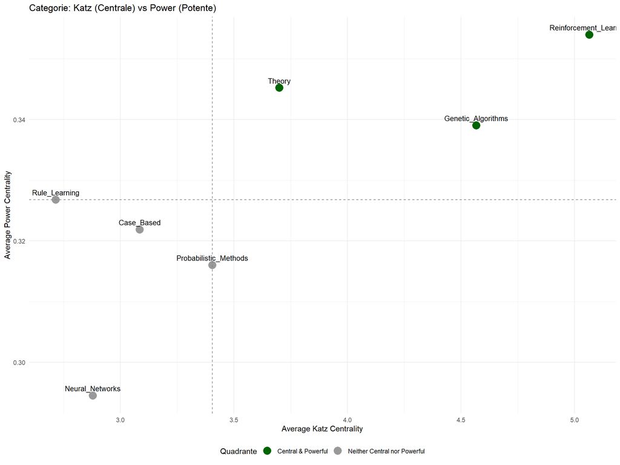

```r
category_stats <- data.frame(
    category = V(graph)$category,
    katz = katz,
    power = p) %>%
  group_by(category) %>%
  summarise(
    avg_katz = mean(katz),
    avg_power = mean(power),
    n_papers = n()
  ) %>%
  ungroup()

# Calcolo le soglie usando la mediana
threshold_katz <- median(category_stats$avg_katz)
threshold_power <- median(category_stats$avg_power)

# Classifico le categorie nei 4 quadranti
category_stats <- category_stats %>%
  mutate(
    is_central = avg_katz > threshold_katz,
    is_powerful = avg_power > threshold_power,
    quadrant = case_when(
      is_central & is_powerful ~ "Central & Powerful",
      is_central & !is_powerful ~ "Central but NOT Powerful",
      !is_central & is_powerful ~ "Powerful but NOT Central",
      TRUE ~ "Neither Central nor Powerful"
    )
  )


ggplot(category_stats, aes(x = avg_katz, y = avg_power, color = quadrant)) +
  geom_point(size = 5) +
  geom_text(aes(label = category), vjust = -0.8, size = 3.5, color = "black") +
  geom_vline(xintercept = threshold_katz, linetype = "dashed", color = "gray50") +
  geom_hline(yintercept = threshold_power, linetype = "dashed", color = "gray50") +
  scale_color_manual(values = c(
    "Central & Powerful" = "darkgreen",
    "Central but NOT Powerful" = "blue",
    "Powerful but NOT Central" = "red",
    "Neither Central nor Powerful" = "gray60"
  )) +
  labs(
    x = "Average Katz Centrality",
    y = "Average Power Centrality",
    title = "Categorie: Katz (Centrale) vs Power (Potente)",
    color = "Quadrante"
  ) +
  theme_minimal() +
  theme(legend.position = "bottom")
```

Una categoria “mediamente” potente e per nulla centrale è la Rule_Learning.

Invece la categoria più centrale possibile rimanndo a “mediamente” e bassa power è Probabilistic_Methods.

Studiando la Correlazione di Kendall tra Katz e Power ottengo che :

```r
cor(katz, p, method="kendall")
```

```
## [1] 0.5634994
```

La correlazione di Kendall tra Katz e Power è circa 0.56

Dunque i due indici sono legati ma misurano aspetti leggermente diversi della centralità.

Mostro ora la rete dei paper.

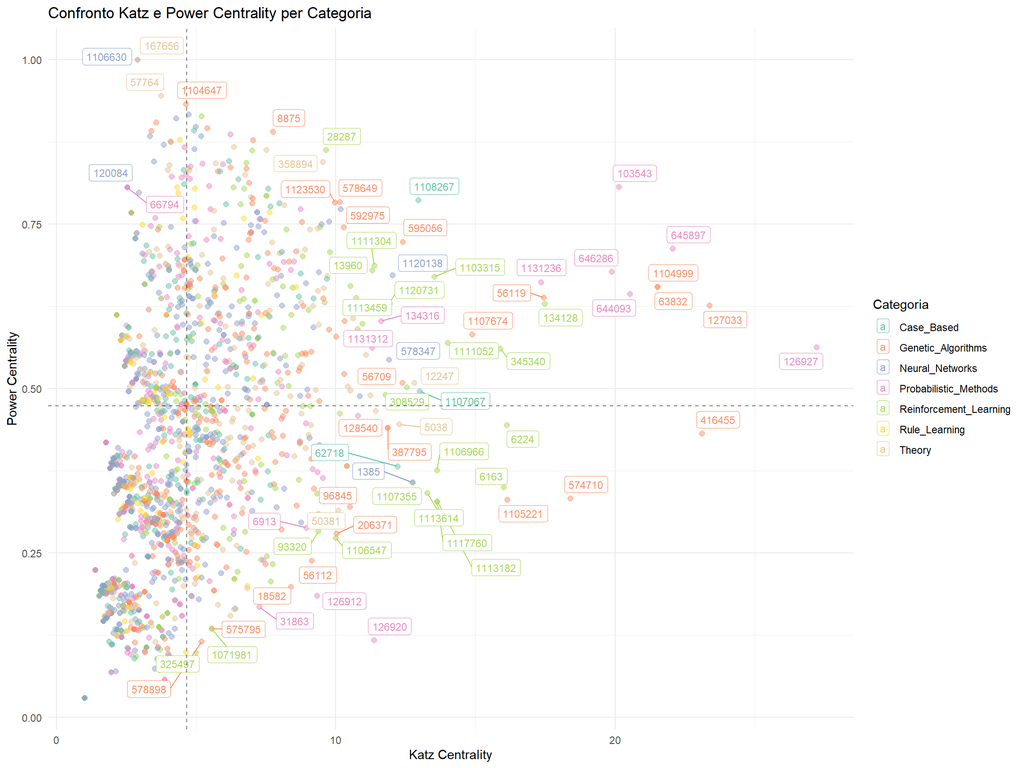

```r
nodes <- graph %>% activate(nodes) %>% as_tibble()

# Calcolo i quantili al 75% per Katz e Power:

q_katz <- quantile(nodes$katz, 0.75)
q_power <- quantile(nodes$power, 0.75)


top_nodes <- nodes %>% filter(katz > q_katz | power > q_power)

ggplot(nodes, aes(x = katz, y = power, color = category)) +
  geom_point(alpha = 0.5, size = 2) +
  geom_label_repel(data = top_nodes, aes(label = name),
                   max.overlaps = 15, size = 3) +
  geom_hline(yintercept = q_power, linetype = "dashed", alpha = 0.5) +
  geom_vline(xintercept = q_katz, linetype = "dashed", alpha = 0.5) +
  scale_color_brewer(palette = "Set2") +
  labs(title = "Confronto Katz e Power Centrality per Categoria",
       x = "Katz Centrality", y = "Power Centrality",
       color = "Categoria") +
  theme_minimal()
```

Spiccano i paper della categoria Probabilistic_Methods come maggiormente centrali e potenti.

## Domanda 8 : Visualizza la rete tra categorie con colore degli archi proporzionale al flusso di citazioni.

- Plot 1 : dimensione dei nodi proporzionale alla Power
- Plot 2 : dimensione dei nodi proporzionale alla Katz Centrality

Nota che ho normalizzato i valori così da rendere i plot più esplicativi.

```r
# Creo ala matrice del flusso di citazioni tra categorie
categories <- sort(unique(V(graph)$category))
flow_matrix <- matrix(0, nrow = length(categories), ncol = length(categories),
                      dimnames = list(categories, categories))

# Popolo la matrice contando le citazioni tra categorie
edgelist <- get.edgelist(graph, names = FALSE)
for (i in 1:nrow(edgelist)) {
  from_cat <- V(graph)$category[edgelist[i, 1]]
  to_cat <- V(graph)$category[edgelist[i, 2]]
  flow_matrix[from_cat, to_cat] <- flow_matrix[from_cat, to_cat] + 1
}
# Elimino i self-loops
diag(flow_matrix) <- 0

# Creo poi il grafo delle categorie
g_cat <- graph_from_adjacency_matrix(flow_matrix, mode = "directed", weighted = TRUE)

# Normalizzo Katz e Power
V(g_cat)$avg_katz <- category_stats$avg_katz[match(V(g_cat)$name, category_stats$category)]
V(g_cat)$avg_power <- category_stats$avg_power[match(V(g_cat)$name, category_stats$category)]

V(g_cat)$katz_norm <- (V(g_cat)$avg_katz - min(V(g_cat)$avg_katz)) /
                      (max(V(g_cat)$avg_katz) - min(V(g_cat)$avg_katz))
V(g_cat)$power_norm <- (V(g_cat)$avg_power - min(V(g_cat)$avg_power)) /
                       (max(V(g_cat)$avg_power) - min(V(g_cat)$avg_power))

# Dimensioni nodi normalizzate
V(g_cat)$size_katz <- 15 + 35 * V(g_cat)$katz_norm
V(g_cat)$size_power <- 15 + 35 * V(g_cat)$power_norm

# Colori e spessore archi basati sul peso
weight_breaks <- quantile(E(g_cat)$weight, probs = seq(0, 1, 0.2))
E(g_cat)$weight_class <- cut(E(g_cat)$weight, breaks = weight_breaks,
                              labels = c("Molto Basse", "Basse", "Medie", "Alte", "Molto Alte"),
                              include.lowest = TRUE)

edge_colors <- c("Molto Basse" = "#fee5d9", "Basse" = "#fcae91", "Medie" = "#fb6a4a",
                 "Alte" = "#de2d26", "Molto Alte" = "#a50f15")

E(g_cat)$color <- edge_colors[E(g_cat)$weight_class]
E(g_cat)$width <- 1 + 5 * E(g_cat)$weight / max(E(g_cat)$weight)

# Layout circolare
layout_cat <- layout_in_circle(g_cat)
```

Vediamo ora 2 plot :

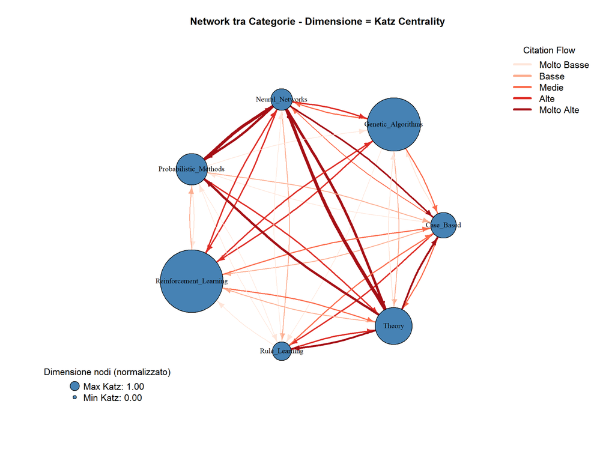

```r
# PLOT 1: Katz - Valori normalizzati

plot(
  g_cat,
  vertex.size = V(g_cat)$size_katz,
  vertex.color = "steelblue",
  vertex.label = V(g_cat)$name,
  vertex.label.cex = 0.85,
  vertex.label.color = "black",
  vertex.label.dist = 0,
  vertex.frame.color = "black",
  edge.width = E(g_cat)$width,
  edge.arrow.size = 0.8,
  edge.color = E(g_cat)$color,
  edge.curved = 0.1,
  layout = layout_cat,
  main = "Network tra Categorie - Dimensione = Katz Centrality",
  margin = 0.1
)

# Legenda con valori fissi 0 e 1
legend("bottomleft",
       legend = c("Max Katz: 1.00", "Min Katz: 0.00"),
       pch = 21, pt.bg = "steelblue", pt.cex = c(2.5, 1), bty = "n",
       title = "Dimensione nodi (normalizzato)", cex = 1.1)

legend("topright",
       legend = names(edge_colors),
       col = edge_colors,
       lwd = 4,
       bty = "n",
       title = "Citation Flow",
       cex = 1.1)
```

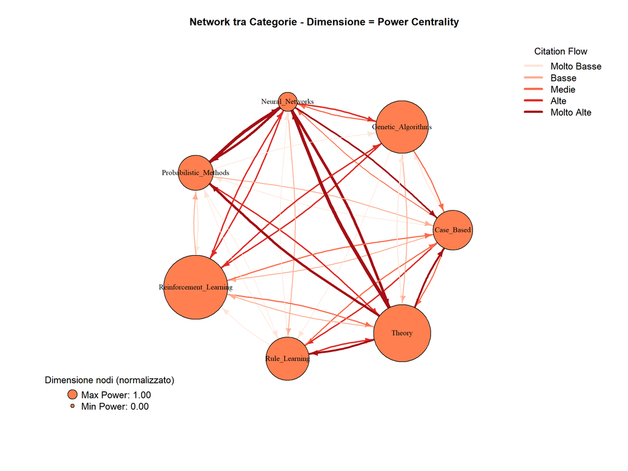

```r
# PLOT 2: Power - Valori normalizzati
plot(
  g_cat,
  vertex.size = V(g_cat)$size_power,
  vertex.color = "coral",
  vertex.label = V(g_cat)$name,
  vertex.label.cex = 0.85,
  vertex.label.color = "black",
  vertex.label.dist = 0,
  vertex.frame.color = "black",
  edge.width = E(g_cat)$width,
  edge.arrow.size = 0.8,
  edge.color = E(g_cat)$color,
  edge.curved = 0.1,
  layout = layout_cat,
  main = "Network tra Categorie - Dimensione = Power Centrality",
  margin = 0.1
)

# Legenda con valori fissi 0 e 1
legend("bottomleft",
       legend = c("Max Power: 1.00", "Min Power: 0.00"),
       pch = 21, pt.bg = "coral", pt.cex = c(2.5, 1), bty = "n",
       title = "Dimensione nodi (normalizzato)", cex = 1.1)

legend("topright",
       legend = names(edge_colors),
       col = edge_colors,
       lwd = 4,
       bty = "n",
       title = "Citation Flow",
       cex = 1.1)
```

Poi possiamo notare come Neural_Ntwork, pur essendo poco potente e centrale, riceve e invia molte più citazioni rispetto a Genetic_Alghoritms che invece è molto più centrale e potente.

## Domanda 9 : I paper con alta centralità tendono ad essere interdisciplinari ?

Per poter rispondere, serve dapprima capire quando un paper può esser considerato interdisciplinare.

Iniziamo col dire che un nodo è eterogeneo se è dissimile dai vicini.

L’eterogeneità può essere integrata nella centralità. Infatti i nodi che ricevono archi da nodi tra loro eterogenei, sono considerati più importanti rispetto a quelli che ricevono archi da nodi molto simili tra loro.

Per fare ciò, sfruttiamo la Rao Quadratic Entropy, ove l’idea è che Rao è grande quando:

- La distribuzione è uniforme (distribuzione su molti elementi)
- Gli elementi sono molto diversi tra loro (dissimilarità alta)

### Calcolo della Rao Quadratic Entropy

Per un grafo diretto (come quello che abbiamo qui), ho 2 opzioni per definire i vicini di un nodo :

- Out-neighbors (nodi citati): analizzando l’eterogeneità delle categorie che il nodo i cita
- In-neighbors (nodi citanti): analizzando l’eterogeneità delle categorie che citano il nodo i

Nel contesto di un citation network, l’opzione che io reputo più sensata è analizzare gli out-neighbors, misurando quanto è interdisciplinare il pattern di citazioni in uscita.

Rao dunque misura quanto sono diverse tra loro le categorie che il paper i cita.

```r
node_categories <- V(graph)$category
categories <- sort(unique(node_categories))
k <- length(categories)
n <- vcount(graph)
```

### STEP 1 : Creare una matrice di flusso F

Per farlo ricorro all’uso della matrice indicatrice C, che vado a creare.

Essa è una matrice n × k (paper × categorie) dove ogni elemento vale:

- C[i, c] = 1 se il paper i appartiene alla categoria c
- C[i, c] = 0 altrimenti

F è una (7×7) che rappresenta quante citazioni esistono tra categorie di paper.

Qui abbiamo 7 categorie e 5429 citazioni totali.

Ottengo la matrice di Flusso F in questo modo :

- A × C : Prodotto tra matrice di adiacenza (n × n) e matrice indicatrice (n × k) → risultato (n × k)

  Per ogni paper i, conto quanti paper cita in ciascuna categoria
- t(C) × (A × C) : Prodotto tra C trasposta (k × n) e il risultato precedente (n × k) → risultato (k × k)

  Aggrego poi per categoria di partenza

  F[c1, c2] = somma di tutte le citazioni da paper di categoria c1 a paper di categoria c2

```r
# Matrice Indicatrice C
C <- matrix(0, nrow = n, ncol = k)
colnames(C) <- categories

for (c_idx in 1:k) {
  C[, c_idx] <- as.numeric(node_categories == categories[c_idx])
}

# Matrice di flusso F
F <- t(C) %*% A %*% C

rownames(F) <- categories
colnames(F) <- categories
```

F rappresenta i “profili di citazione” delle categorie:

- Ogni riga di F mostra quali categorie una determinata categoria tende a citare
- Due categorie sono simili se hanno profili di citazione simili (citano le stesse altre categorie in proporzioni simili)

### STEP 2 : Cosine Similarity tra categorie

Questo blocco calcola la cosine similarity tra tutte le coppie di categorie. La cosine similarity misura quanto sono simili due categorie in base ai loro “profili di citazione” (quali altre categorie tendono a citare).

La normalizzazione garantisce che la similarità dipenda solo dall’orientamento dei vettori (pattern di citazione), non dalla loro magnitudine (volume totale di citazioni).

```r
# Funzione per calcolare norma euclidea di un vettore
euclidean <- function(x) {sqrt(sum(x^2))}

# Calcolo delle norme euclidee per ogni riga di F
norms <- apply(F, 1, euclidean)

# Mi creo la matrice diagonale con 1/norma
D_norm <- diag(1 / norms)

# Per gestire le categorie senza citazioni
D_norm[!is.finite(D_norm)] <- 0

# Cosine similarity
S_cat <- D_norm %*% F %*% t(F) %*% D_norm

rownames(S_cat) <- categories
colnames(S_cat) <- categories
```

### STEP 3 : Dissimilarità D tra CATEGORIE

```r
# Conversione della similarità in dissimilarità
D <- 1 - S_cat

# Rendo la matrice simmetrica
D <- (D + t(D)) / 2

# Pongo la diagonale a 0 poichè una categoria non è dissimile da se stessa
diag(D) <- 0

summary(D[D > 0])
```

```
##    Min. 1st Qu.  Median    Mean 3rd Qu.    Max.
##  0.7784  0.8566  0.9260  0.9110  0.9612  0.9932
```

Mostro qui la heatmap di Dissimilarità tra Categorie

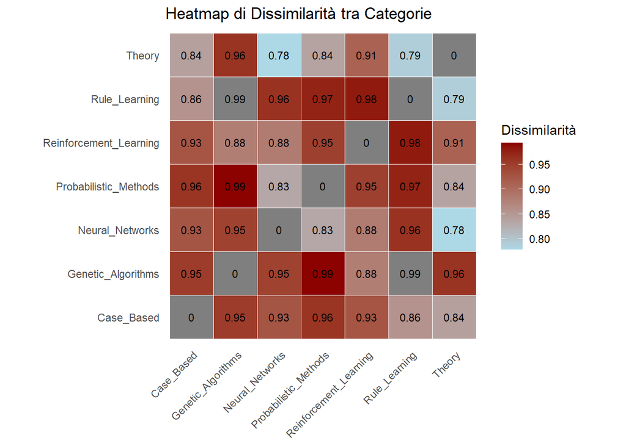

```r
# Converto in formato long
D_long <- as.data.frame(as.matrix(D)) %>%
  mutate(Categoria1 = rownames(.)) %>%
  pivot_longer(cols = -Categoria1, names_to = "Categoria2", values_to = "Dissimilarita")

ggplot(D_long, aes(x = Categoria1, y = Categoria2, fill = Dissimilarita)) +
  geom_tile(color = "white") +
  geom_text(aes(label = round(Dissimilarita, 2)), size = 3) +
  scale_fill_gradient(low = "lightblue", high = "darkred",
                      limits = c(0.7784, 0.9932),
                      name = "Dissimilarità") +
  theme_minimal() +
  theme(axis.text.x = element_text(angle = 45, hjust = 1, vjust = 1),
        axis.title = element_blank(),
        panel.grid = element_blank()) +
  labs(title = "Heatmap di Dissimilarità tra Categorie") +
  coord_fixed()
```

Dato che ottengo un valore alto per la Dissimilarità media : 0.911, significa che le categorie sono mediamente molto dissimili tra loro.

Questo è ottimo per la Rao Entropy perché significa che posso distinguere bene l’interdisciplinarità dato che le categorie son ben separate.

### STEP 4: Distribuzione CATEGORIE per ogni PAPER

Creare la matrice P che contiene, per ogni paper, la distribuzione di probabilità delle categorie che cita.

Tale distribuzione P è essenziale nella formula di Rao (ha come dimensione : paper x categorie).

```r
# Creo una matrice n x 7 piena di 0
P <- matrix(0, nrow = n, ncol = k)
colnames(P) <- categories

# Faccio ora un loop sui papers, per ognuno vado a prendere i paper che esso cita
for (i in 1:n) {

  # Out-neighbors del paper i (paper citati da i)
  out_neighbors <- which(A[i, ] > 0)

  if (length(out_neighbors) > 0) {

    # Estraggo tutte le categorie dei paper citati
    neighbor_cats <- node_categories[out_neighbors]

    # Calcolo le proporzioni per ogni categoria
    for (c in categories) {

      # Per ogni categoria, vedo infine P[i, c] che è : il numero di paper citati nella categoria c / totale paper citati
      P[i, c] <- sum(neighbor_cats == c) / length(out_neighbors)

      }
  }
}

papers_with_citations <- sum(rowSums(P) > 0)

cat("  Matrice P calcolata:", nrow(P), "×", ncol(P), "\n")
```

```
##   Matrice P calcolata: 2708 × 7
```

```r
cat("  Paper con almeno 1 citazione out:", papers_with_citations, "\n\n")
```

```
##   Paper con almeno 1 citazione out: 1565
```

### STEP 5: Calcolo RAO per ogni PAPER

La funzione implementa la formula della Rao Quadratic Entropy in forma matriciale.

Ho che :

- p è il vettore di lunghezza k (7 qui) con le proporzioni delle categorie per un singolo paper
- D è la matrice k × k di dissimilarità tra categorie

La funzione diag(p) crea una matrice diagonale k × k con i valori di p sulla diagonale.

```r
# Funzione pr calcolare Rao
rao <- function(p, D) {
  D_mat <- as.matrix(D)
  x <- diag(p) %*% D_mat %*% diag(p)
  return(sum(as.numeric(x)))
}

# Applico poi Rao ad ogni riga di P (ogni paper)
rao_values <- apply(P, 1, function(p_i) rao(p_i, D))

# Assegno infine nomi ai valori Rao
names(rao_values) <- V(graph)$name
```

### Step 6 : Statistiche : Specializzazione vs Interdisciplinarità

```r
# Calcolo la out-degree per ogni nodo
out_degrees <- degree(graph, mode = "out")

# Classificazione dei paper
terminali <- sum(out_degrees == 0)
interdisciplinari <- sum(rao_values > 0)
specializzati <- sum(out_degrees > 0 & rao_values == 0)

# Verifica totale
totale <- vcount(graph)
check_sum <- terminali + interdisciplinari + specializzati

cat("1. Paper TERMINALI (non citano nessuno):\n")
```

```
## 1. Paper TERMINALI (non citano nessuno):
```

```r
cat("   Numero:", terminali, "\n")
```

```
##    Numero: 1143
```

```r
cat("   Percentuale:", round(terminali / totale * 100, 2), "%\n")
```

```
##    Percentuale: 42.21 %
```

```r
cat("2. Paper SPECIALIZZATI (citano solo la propria categoria):\n")
```

```
## 2. Paper SPECIALIZZATI (citano solo la propria categoria):
```

```r
cat("   Numero:", specializzati, "\n")
```

```
##    Numero: 1265
```

```r
cat("   Percentuale:", round(specializzati / totale * 100, 2), "%\n")
```

```
##    Percentuale: 46.71 %
```

```r
cat("   → Out-degree > 0, ma Rao = 0\n")
```

```
##    → Out-degree > 0, ma Rao = 0
```

```r
cat("3. Paper INTERDISCIPLINARI (citano categorie diverse):\n")
```

```
## 3. Paper INTERDISCIPLINARI (citano categorie diverse):
```

```r
cat("   Numero:", interdisciplinari, "\n")
```

```
##    Numero: 300
```

```r
cat("   Percentuale:", round(interdisciplinari / totale * 100, 2), "%\n")
```

```
##    Percentuale: 11.08 %
```

```r
cat("   → Out-degree > 0 e Rao > 0\n")
```

```
##    → Out-degree > 0 e Rao > 0
```

```r
cat("TOTALE:\n")
```

```
## TOTALE:
```

```r
cat("   Paper totali:", totale, "\n")
```

```
##    Paper totali: 2708
```

```r
cat("   Somma classificazioni:", check_sum, "\n")
```

```
##    Somma classificazioni: 2708
```

```r
cat("   Verifica (devono coincidere):", ifelse(totale == check_sum, "✓ OK", "✗ ERRORE"), "\n\n")
```

```
##    Verifica (devono coincidere): ✓ OK
```

```r
# Statistiche aggiuntive
cat("Paper con citazioni out (specializzati + interdisciplinari):\n")
```

```
## Paper con citazioni out (specializzati + interdisciplinari):
```

```r
cat("   Numero:", specializzati + interdisciplinari, "\n")
```

```
##    Numero: 1565
```

```r
cat("   Percentuale:", round((specializzati + interdisciplinari) / totale * 100, 2), "%\n\n")
```

```
##    Percentuale: 57.79 %
```

```r
# Statistiche Rao per paper interdisciplinari
rao_interdisciplinari <- rao_values[rao_values > 0]

cat("Statistiche Rao per paper interdisciplinari (Rao > 0):\n")
```

```
## Statistiche Rao per paper interdisciplinari (Rao > 0):
```

```r
summary(rao_interdisciplinari)
```

```
##    Min. 1st Qu.  Median    Mean 3rd Qu.    Max.
## 0.07763 0.31467 0.40337 0.38984 0.46504 0.69210
```

```r
# Distribuzione out-degree per tipo
cat("Out-degree medio per tipo:\n")
```

```
## Out-degree medio per tipo:
```

```r
cat("   Paper specializzati:", round(mean(out_degrees[out_degrees > 0 & rao_values == 0]), 2), "\n")
```

```
##    Paper specializzati: 2.35
```

```r
cat("   Paper interdisciplinari:", round(mean(out_degrees[rao_values > 0]), 2), "\n\n")
```

```
##    Paper interdisciplinari: 8.17
```

Dunque su 1565 paper che almeno 1 citazione ad un altro paper, solo 300 citano paper di una categoria diversa dalla propria.

Interpretazione dei valori :

- Rao = 0: Paper che non cita nessuno, oppure cita solo paper di una categoria
- Rao basso (es. 0.1): Paper specializzato, cita principalmente categorie simili tra loro
- Rao medio (es. 0.3-0.5): Paper moderatamente interdisciplinare
- Rao alto (es. > 0.7): Paper fortemente interdisciplinare, cita molte categorie diverse e dissimili

### STEP 7 : Aggiungo RAO come attributo del grafo e Calcolo della Betweenness Centrality

```r
V(graph)$rao_entropy <- rao_values

graph <- graph %>%
  activate(nodes) %>%
  mutate(
    betweenness = centrality_betweenness()
  )
```

### STEP 8 : Lavoro ora sul rispondere alla domanda : I paper con alta centralità tendono ad essere interdisciplinari ?

```r
# Creo il dataframe completo
df_analysis <- data.frame(
  paper = V(graph)$name,
  category = V(graph)$category,
  rao_entropy = rao_values,
  pagerank = V(graph)$pagerank,
  betweenness = V(graph)$betweenness,
  degree_out = degree(graph, mode = "out"),
  stringsAsFactors = FALSE
)

# Filtro e tengo solo paper con citazioni out (altrimenti Rao = 0 per definizione)
df_active <- df_analysis[df_analysis$degree_out > 0, ]


cat("Dataset per l'analisi:\n")
```

```
## Dataset per l'analisi:
```

```r
cat("  Paper totali:", nrow(df_analysis), "\n")
```

```
##   Paper totali: 2708
```

```r
cat("  Paper con citazioni out:", nrow(df_active), "\n")
```

```
##   Paper con citazioni out: 1565
```

```r
cat("  (Solo questi possono avere Rao > 0)\n\n")
```

```
##   (Solo questi possono avere Rao > 0)
```

Identificazione dei paper con alta Centralità (ossia nel top 10%).

```r
# Definisco una threshold per "alta centralità"
threshold_pagerank <- quantile(df_active$pagerank, 0.90)
threshold_betweenness <- quantile(df_active$betweenness, 0.90)

# Classifica paper
df_active$high_pagerank <- df_active$pagerank >= threshold_pagerank
df_active$high_betweenness <- df_active$betweenness >= threshold_betweenness
df_active$high_centrality <- df_active$high_pagerank | df_active$high_betweenness

# Statistiche
n_high_centrality <- sum(df_active$high_centrality)
n_low_centrality <- sum(!df_active$high_centrality)

cat("Paper ad ALTA centralità (top 10% PageRank o Betweenness):", n_high_centrality, "\n")
```

```
## Paper ad ALTA centralità (top 10% PageRank o Betweenness): 295
```

```r
cat("Paper a BASSA centralità:", n_low_centrality, "\n\n")
```

```
## Paper a BASSA centralità: 1270
```

```r
cat("Threshold utilizzati:\n")
```

```
## Threshold utilizzati:
```

```r
cat("  PageRank >= ", format(threshold_pagerank, scientific = TRUE), "\n", sep = "")
```

```
##   PageRank >= 5.315644e-04
```

```r
cat("  Betweenness >= ", round(threshold_betweenness, 4), "\n\n", sep = "")
```

```
##   Betweenness >= 141.2167
```

Distribuzione Rao Entropy per livello di centralità

```r
# Separo i due gruppi
high_centrality_papers <- df_active[df_active$high_centrality, ]
low_centrality_papers <- df_active[!df_active$high_centrality, ]

# Statistiche descrittive per ALTA centralità
cat("Paper ad ALTA centralità (n =", nrow(high_centrality_papers), "):\n")
```

```
## Paper ad ALTA centralità (n = 295 ):
```

```r
summary(high_centrality_papers$rao_entropy)
```

```
##    Min. 1st Qu.  Median    Mean 3rd Qu.    Max.
##  0.0000  0.0000  0.0000  0.1313  0.3123  0.6921
```

```r
cat("  % con Rao > 0 (interdisciplinari):", round(sum(high_centrality_papers$rao_entropy > 0) / nrow(high_centrality_papers) * 100, 2), "%\n\n")
```

```
##   % con Rao > 0 (interdisciplinari): 34.24 %
```

```r
# Statistiche descrittive per BASSA centralità
cat("Paper a BASSA centralità (n =", nrow(low_centrality_papers), "):\n")
```

```
## Paper a BASSA centralità (n = 1270 ):
```

```r
summary(low_centrality_papers$rao_entropy)
```

```
##    Min. 1st Qu.  Median    Mean 3rd Qu.    Max.
## 0.00000 0.00000 0.00000 0.06159 0.00000 0.68674
```

```r
cat("  % con Rao > 0 (interdisciplinari):", round(sum(low_centrality_papers$rao_entropy > 0) / nrow(low_centrality_papers) * 100, 2), "%\n\n")
```

```
##   % con Rao > 0 (interdisciplinari): 15.67 %
```

Dunque si, i paper con alta centralità tendono ad essere interdisciplinari rispetto a quelli con un basso livello di centralità.

Mostriamo con un grafico i dati ottenuti.

Grafico : Alta centralità → Maggiore interdisciplinarità

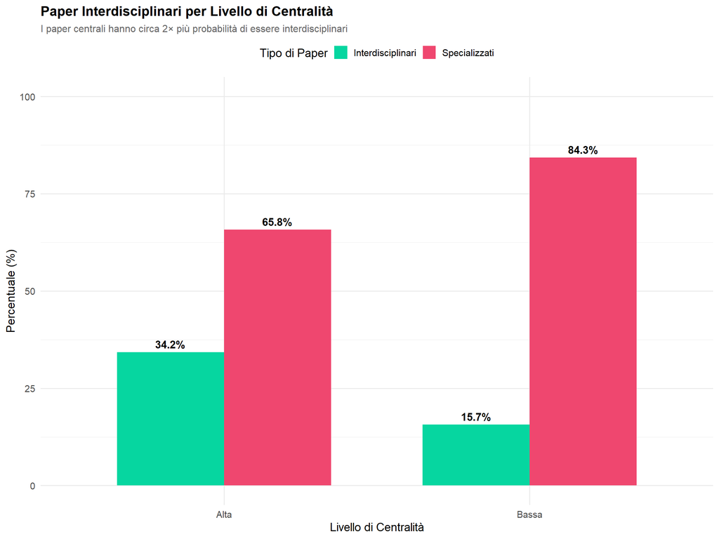

```r
# Preparo i dati per il grafico (manualmente senza tidyr)
prop_data <- data.frame(
  Centralita = c("Alta", "Bassa"),
  Interdisciplinari = c(34.24, 15.67),
  Specializzati = c(65.76, 84.33)
)

# Reshape manuale
prop_data_long <- data.frame(
  Centralita = rep(prop_data$Centralita, times = 2),
  Tipo = rep(c("Interdisciplinari", "Specializzati"), each = 2),
  Percentuale = c(prop_data$Interdisciplinari, prop_data$Specializzati)
)

# Barplot
p1 <- ggplot(prop_data_long, aes(x = Centralita, y = Percentuale, fill = Tipo)) +
  geom_bar(stat = "identity", position = "dodge", width = 0.7) +
  geom_text(aes(label = paste0(round(Percentuale, 1), "%")),
            position = position_dodge(width = 0.7),
            vjust = -0.5, size = 4.5, fontface = "bold") +
  scale_fill_manual(values = c("Interdisciplinari" = "#06D6A0",
                                "Specializzati" = "#EF476F")) +
  labs(title = "Paper Interdisciplinari per Livello di Centralità",
       subtitle = "I paper centrali hanno circa 2× più probabilità di essere interdisciplinari",
       x = "Livello di Centralità",
       y = "Percentuale (%)",
       fill = "Tipo di Paper") +
  theme_minimal(base_size = 14) +
  theme(plot.title = element_text(face = "bold", size = 16),
        plot.subtitle = element_text(size = 12, color = "gray40"),
        legend.position = "top") +
  ylim(0, 100)

print(p1)
```

## Domanda 10 : I paper interdisciplinari (alto Rao da out-degree) sono più influenti (alto in-degree/PageRank) ?

Definiamo questa “influenza” usando le metriche di centralità : PageRank, In-degree e Betweenness.

Confronto l’influenza tra paper interdisciplinari (Rao > 0) vs specializzati (Rao = 0).

Sto misurando:

- Input diversity (Rao da out-degree): quanto sono diversificato in ciò che cito
- Output impact (Influenza da in-degree): quanto impatto ho sugli altri

Queste due dimensioni insieme danno un quadro completo della posizione di un paper nella rete.

Nota che Katz e PageRank sono concettualmente simili, lasciamo fuori la Katz Ceantrality da questa analisi.

Recap :

- PageRank: “quanto sono importanti i miei citatori?”
- In-degree: “quante citazioni ricevo?”
- Betweenness: “quanto connetto parti diverse della rete?”

Vediamo ora questi grafici per rispondere alla domanda :

Grafico 1 : Betweenness : Paper Interdisciplinari = ponti tra Discipline

Grafico 2 : Confronto Multidimensionale: Interdisciplinari vs Specializzati

Grafico 3 : Betweenness vs Page rank, focus su interdisciplinari

Grafico 4 : Facet per categoria

```r
# Definisco il tipo in base a Rao
df_active$tipo <- ifelse(df_active$rao_entropy > 0, "Interdisciplinare", "Specializzato")
df_active$tipo <- factor(df_active$tipo, levels = c("Specializzato", "Interdisciplinare"))

# Calcolo le medie di betweenness per i due gruppi
inter_betweenness <- df_active %>%
  filter(rao_entropy > 0, !is.na(betweenness)) %>%
  summarise(m = mean(betweenness)) %>%
  pull(m)

spec_betweenness <- df_active %>%
  filter(rao_entropy == 0, !is.na(betweenness)) %>%
  summarise(m = mean(betweenness)) %>%
  pull(m)
```

### Grafico 1 : Betweeness

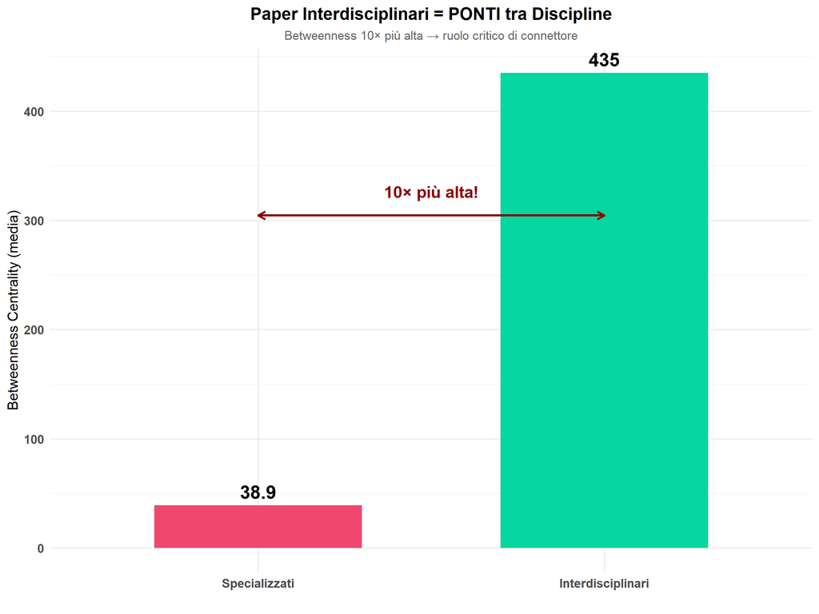

```r
betw_data <- data.frame(
  Tipo = factor(c("Interdisciplinari", "Specializzati"),
                levels = c("Specializzati", "Interdisciplinari")),
  Betweenness = c(inter_betweenness, spec_betweenness),
  Label = c(paste0(round(inter_betweenness, 1)),
            paste0(round(spec_betweenness, 1)))
)

p1 <- ggplot(betw_data, aes(x = Tipo, y = Betweenness, fill = Tipo)) +
  geom_bar(stat = "identity", width = 0.6) +
  geom_text(aes(label = Label),
            vjust = -0.5, size = 7, fontface = "bold") +
  scale_fill_manual(values = c("Specializzati" = "#EF476F",
                                "Interdisciplinari" = "#06D6A0")) +
  labs(title = "Paper Interdisciplinari = PONTI tra Discipline",
       subtitle = "Betweenness 10× più alta → ruolo critico di connettore",
       x = "",
       y = "Betweenness Centrality (media)") +
  theme_minimal(base_size = 15) +
  theme(plot.title = element_text(face = "bold", size = 18, hjust = 0.5),
        plot.subtitle = element_text(size = 13, color = "gray40", hjust = 0.5),
        legend.position = "none",
        axis.text = element_text(size = 13, face = "bold")) +
  annotate("segment",
           x = 1, xend = 2,
           y = max(betw_data$Betweenness) * 0.7,
           yend = max(betw_data$Betweenness) * 0.7,
           arrow = arrow(ends = "both", length = unit(0.3, "cm")),
           color = "darkred", size = 1.2) +
  annotate("text",
           x = 1.5,
           y = max(betw_data$Betweenness) * 0.75,
           label = "10× più alta!",
           size = 6,
           fontface = "bold",
           color = "darkred")

print(p1)
```

I paper interdisciplinari (Rao > 0) hanno una Betweenness Centrality molto più alta.

Il che sembra snsato in quanto si troveranno a connettere parti distinte della rete molto più dei paper specializzati.

### Grafico 2 : Confronto Multidimensionale: Interdisciplinari vs Specializzati

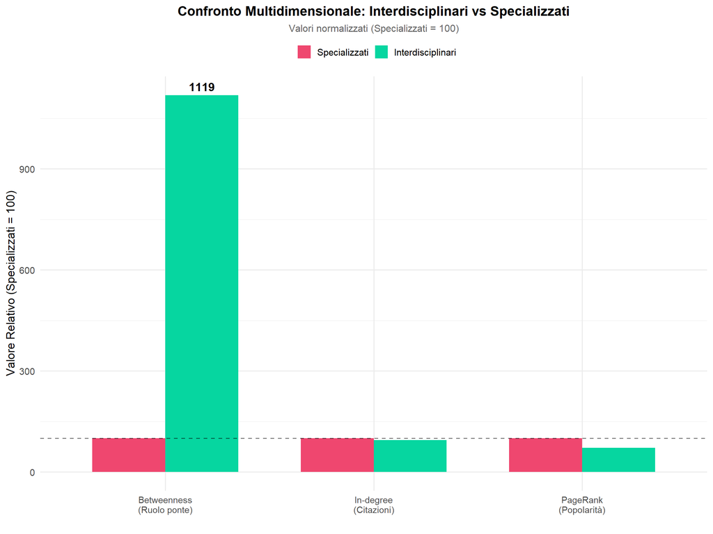

```r
# Se gli specializzati hanno valore 100, quanto hanno gli interdisciplinari ?
comparison_data <- data.frame(
  Metrica = rep(c("PageRank\n(Popolarità)",
                  "In-degree\n(Citazioni)",
                  "Betweenness\n(Ruolo ponte)"), each = 2),
  Tipo = rep(c("Specializzati", "Interdisciplinari"), times = 3),
  Valore_Norm = c(
    # PageRank (normalizzato al valore specializzati = 100)
    100, 72,
    # In-degree
    100, 95,
    # Betweenness
    100, 1119
  )
)

comparison_data$Tipo <- factor(comparison_data$Tipo,
                                levels = c("Specializzati", "Interdisciplinari"))

p2 <- ggplot(comparison_data, aes(x = Metrica, y = Valore_Norm, fill = Tipo)) +
  geom_bar(stat = "identity", position = "dodge", width = 0.7) +
  geom_hline(yintercept = 100, linetype = "dashed", color = "black", alpha = 0.5) +
  geom_text(aes(label = ifelse(Valore_Norm > 150, Valore_Norm, "")),
            position = position_dodge(width = 0.7),
            vjust = -0.5, size = 5, fontface = "bold") +
  scale_fill_manual(values = c("Specializzati" = "#EF476F",
                                "Interdisciplinari" = "#06D6A0")) +
  labs(title = "Confronto Multidimensionale: Interdisciplinari vs Specializzati",
       subtitle = "Valori normalizzati (Specializzati = 100)",
       x = "",
       y = "Valore Relativo (Specializzati = 100)",
       fill = "") +
  theme_minimal(base_size = 14) +
  theme(plot.title = element_text(face = "bold", size = 16, hjust = 0.5),
        plot.subtitle = element_text(size = 12, color = "gray40", hjust = 0.5),
        legend.position = "top",
        axis.text.x = element_text(size = 11))

print(p2)
```

Questa maggiore influenza dei paper Interdisciplinari è evidenziata quasi solo nel caso della Betweenness Centrality.

### Grafico 3: Focus solo sui paper interdisciplinari

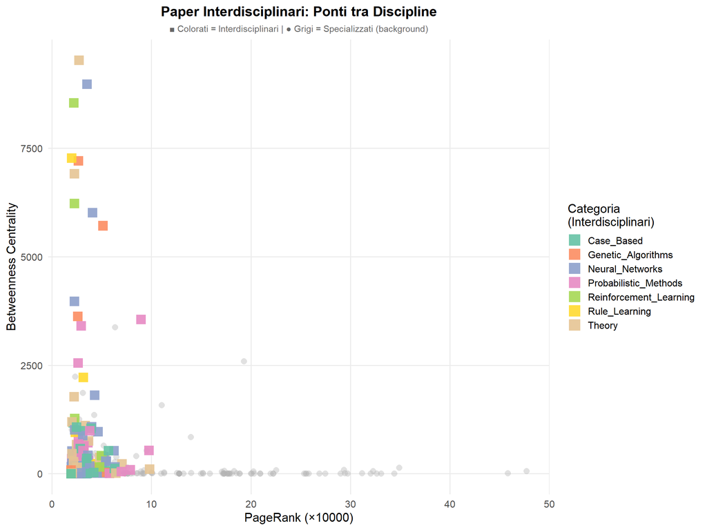

```r
# Aggiungo  la colonna 'tipo'
if (!"tipo" %in% names(df_active)) {
  df_active$tipo <- ifelse(df_active$rao_entropy > 0, "Interdisciplinare", "Specializzato")
  df_active$tipo <- factor(df_active$tipo, levels = c("Specializzato", "Interdisciplinare"))
}


# Evidenzio solo gli interdisciplinari
df_active$highlight <- df_active$tipo == "Interdisciplinare"


p_highlight <- ggplot(df_active, aes(x = pagerank * 10000, y = betweenness)) +

  # Primo layer: specializzati in grigio
  geom_point(data = df_active[!df_active$highlight, ],
             color = "gray70", shape = 16, size = 3, alpha = 0.4) +

  # Secondo layer: interdisciplinari colorati
  geom_point(data = df_active[df_active$highlight, ],
      aes(color = category),
    shape = 15, size = 5, alpha = 0.9) +
    scale_color_brewer(palette = "Set2", name = "Categoria\n(Interdisciplinari)") +
    labs(title = "Paper Interdisciplinari: Ponti tra Discipline",
      subtitle = "■ Colorati = Interdisciplinari | ● Grigi = Specializzati (background)",
       x = "PageRank (×10000)",
       y = "Betweenness Centrality") +
  theme_minimal(base_size = 15) +
  theme(
    plot.title = element_text(face = "bold", size = 17, hjust = 0.5),
    plot.subtitle = element_text(size = 11, color = "gray40", hjust = 0.5),
    legend.position = "right",
    panel.grid.minor = element_blank()
  ) +
  guides(color = guide_legend(override.aes = list(size = 6)))

print(p_highlight)
```

Varie categorie presentano paper con alta betweenness, procedo dunque a fare un faceting per veder meglio la distinzione.

### Grafico 4 : Facet per categoria

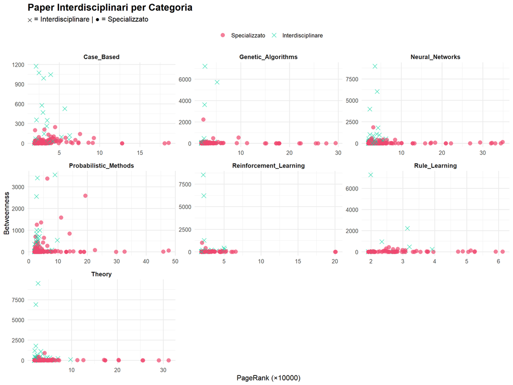

```r
p_facet <- ggplot(df_active, aes(x = pagerank * 10000,
                                  y = betweenness,
                                  color = tipo,
                                  shape = tipo)) +
  geom_point(alpha = 0.7, size = 3) +

  scale_color_manual(values = c("Specializzato" = "#EF476F",
                                 "Interdisciplinare" = "#06D6A0"),
                     name = "") +

  scale_shape_manual(values = c("Specializzato" = 16, "Interdisciplinare" = 4),
                     name = "") +

  facet_wrap(~ category, scales = "free", ncol = 3) +

  labs(title = "Paper Interdisciplinari per Categoria",
       subtitle = "✕ = Interdisciplinare | ● = Specializzato",
       x = "PageRank (×10000)",
       y = "Betweenness") +

  theme_minimal(base_size = 12) +
  theme(plot.title = element_text(face = "bold", size = 16),
        strip.text = element_text(face = "bold", size = 10),
        legend.position = "top")

print(p_facet)
```

I paper interdisciplinari (alto Rao da out-degree) sono più influenti (alto in-degree/PageRank) ?

- Se intendiamo influenza come PageRank/In-degree allora no, infatti gli specializzati sono PIÙ citati (+28% PageRank).
- Se intendiamo invece la Betweeness allora si, gli interdisciplinari hanno +1019% Betweenness. Sono i ponti che connettono discipline diverse, hanno un ruolo importante per la circolazione delle idee.

## Domanda 11 : Quali categorie producono i paper più interdisciplinari ? E quali beneficiano di più dai ponti interdisciplinari?

Considero qui un paper interdisciplinare se cita al di fuori della propria categoria.

Considero invece altri paper che beneficiano da ponti come citati da paper di categoria diversa.

Analisi :

Tabella : Rao medio per categoria

Grafico : % Paper Interdisciplinari per Categoria

Tabella : Top Coppie di categorie per numero di citazioni (paper 1 cita paper 2 tot volte)

Tabella : Bilanciamento ottenuto dall’interdisciplinarità delle categorie

### Interdisciplinarità per Categoria

Rao medio per categoria

```r
# Solo paper con citazioni out
df_active <- df_analysis[df_analysis$degree_out > 0, ]

# Aggrego per categoria
category_stats <- df_active %>%
  group_by(category) %>%
  summarise(
    n_papers = n(),
    rao_medio = mean(rao_entropy),
    perc_interdisciplinari = sum(rao_entropy > 0) / n() * 100,
    # Rao medio solamnte tra interdisciplinari
    rao_medio_inter = mean(rao_entropy[rao_entropy > 0]),
    betweenness_medio = mean(betweenness)
  ) %>%
  arrange(desc(rao_medio))

print(category_stats,
            digits = c(0, 0, 4, 1, 4, 1),
            col.names = c("Categoria", "N Paper", "Rao Medio (tutti)",
                         "% Interdisciplinari", "Rao Medio (inter)", "Betweenness Medio"))
```

```
## # A tibble: 7 × 6
##   category             n_papers rao_medio perc_interdisciplinari rao_medio_inter
##   <chr>                   <int>     <dbl>                  <dbl>           <dbl>
## 1 Theory                    207    0.128                    30.9           0.414
## 2 Reinforcement_Learn…      131    0.0958                   26.7           0.358
## 3 Case_Based                169    0.0900                   21.3           0.423
## 4 Rule_Learning             102    0.0678                   16.7           0.407
## 5 Neural_Networks           456    0.0659                   17.3           0.380
## 6 Probabilistic_Metho…      264    0.0629                   16.7           0.377
## 7 Genetic_Algorithms        236    0.0387                   10.6           0.365
## # ℹ 1 more variable: betweenness_medio <dbl>
```

Dunque la categoria che produce i paper più interdisciplinari è Theory.

Infatti la percentuale di paper interdisciplinari è di circa il 30%, maggiore di tutti gli altri.

### Paper Interdisciplinari per Categoria

Spiego qui con un grafico i dati appena ottenuti nella tabella preedente.

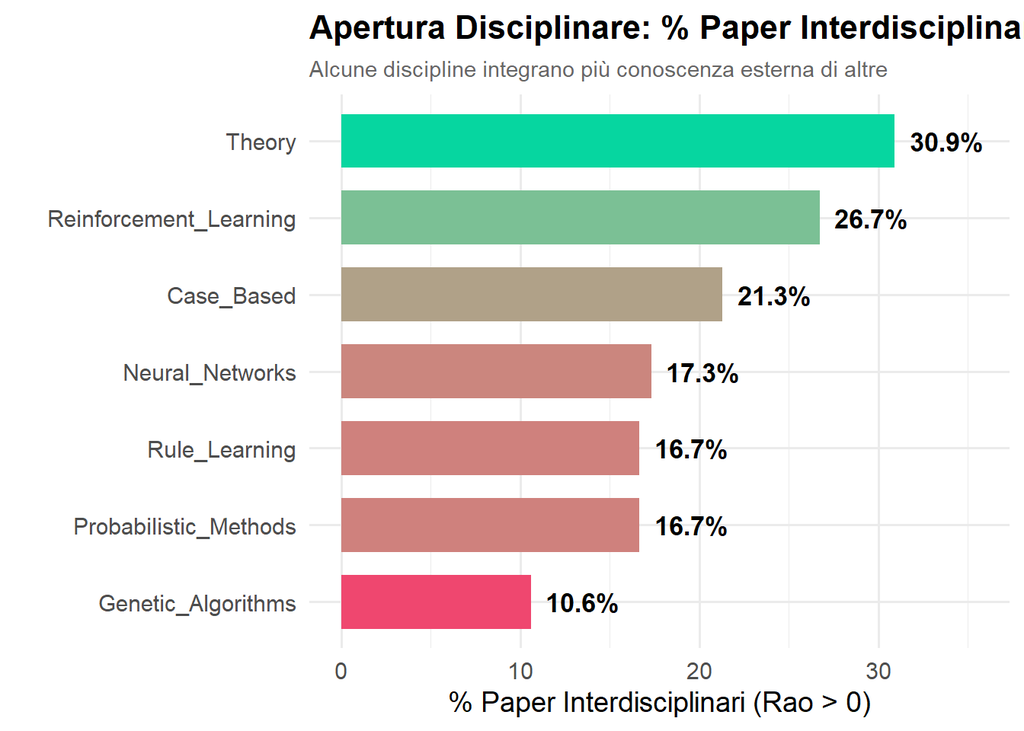

```r
# Barplot con % interdisciplinari
p_categories <- ggplot(category_stats,
                       aes(x = reorder(category, perc_interdisciplinari),
                           y = perc_interdisciplinari,
                           fill = perc_interdisciplinari)) +
  geom_bar(stat = "identity", width = 0.7) +
  geom_text(aes(label = paste0(round(perc_interdisciplinari, 1), "%")),
            hjust = -0.2, size = 4.5, fontface = "bold") +
  scale_fill_gradient(low = "#EF476F", high = "#06D6A0",
                      name = "% Interdisciplinari") +
  coord_flip() +
  labs(title = "Apertura Disciplinare: % Paper Interdisciplinari per Categoria",
       subtitle = "Alcune discipline integrano più conoscenza esterna di altre",
       x = "",
       y = "% Paper Interdisciplinari (Rao > 0)") +
  theme_minimal(base_size = 14) +
  theme(plot.title = element_text(face = "bold", size = 16),
        plot.subtitle = element_text(size = 11, color = "gray40"),
        legend.position = "none") +
  ylim(0, max(category_stats$perc_interdisciplinari) * 1.15)

print(p_categories)
```

### Top Coppie di categorie per numero di citazioni (paper 1 cita paper 2 tot volte)

Vediamo i Top 10 flussi di citazioni cross-categoria (from != to).

Nota che svolgo l’analisi solo per i paper interdisciplinari (che son 300).

```r
# Filtro solo paper interdisciplinari
interdisciplinary_papers <- df_active[df_active$rao_entropy > 0, ]

# cat("Analisi su", nrow(interdisciplinary_papers), "paper interdisciplinari\n\n")

# Per ogni paper interdisciplinare, guardo chi cita
cross_citations <- data.frame()

for (i in 1:nrow(interdisciplinary_papers)) {
  paper_idx <- which(V(graph)$name == interdisciplinary_papers$paper[i])
  cited_indices <- which(A[paper_idx, ] > 0)

  if (length(cited_indices) > 0) {
    source_cat <- interdisciplinary_papers$category[i]
    target_cats <- node_categories[cited_indices]

    # solo citazioni cross-category (from != to)
    for (target_cat in unique(target_cats)) {
      if (source_cat != target_cat) {  # ← FILTRO AGGIUNTO
        n_cit <- sum(target_cats == target_cat)
        cross_citations <- rbind(cross_citations,
                                 data.frame(from = source_cat,
                                           to = target_cat,
                                           weight = n_cit))
      }
    }
  }
}

# Aggrego
cross_summary <- cross_citations %>%
  group_by(from, to) %>%
  summarise(total_citations = sum(weight)) %>%
  arrange(desc(total_citations))

print(head(cross_summary, 20),
            col.names = c("Da Categoria", "A Categoria", "N Citazioni"))
```

```
## # A tibble: 20 × 3
## # Groups:   from [7]
##    from                   to                     total_citations
##    <chr>                  <chr>                            <int>
##  1 Theory                 Neural_Networks                     82
##  2 Probabilistic_Methods  Neural_Networks                     71
##  3 Neural_Networks        Theory                              64
##  4 Theory                 Probabilistic_Methods               52
##  5 Theory                 Rule_Learning                       48
##  6 Neural_Networks        Probabilistic_Methods               46
##  7 Theory                 Case_Based                          44
##  8 Neural_Networks        Reinforcement_Learning              30
##  9 Probabilistic_Methods  Theory                              29
## 10 Reinforcement_Learning Neural_Networks                     28
## 11 Case_Based             Rule_Learning                       27
## 12 Neural_Networks        Genetic_Algorithms                  27
## 13 Reinforcement_Learning Genetic_Algorithms                  27
## 14 Genetic_Algorithms     Reinforcement_Learning              26
## 15 Neural_Networks        Case_Based                          26
## 16 Case_Based             Theory                              25
## 17 Rule_Learning          Theory                              25
## 18 Genetic_Algorithms     Case_Based                          18
## 19 Rule_Learning          Case_Based                          18
## 20 Genetic_Algorithms     Neural_Networks                     15
```

Vediamo nella tabella come la categoria Neural_Networks sia la più citata da una stessa categoria, che è Theory.

Statistiche citazioni cross-categoria

```r
cat("  Totale citazioni cross:", sum(cross_summary$total_citations), "\n")
```

```
##   Totale citazioni cross: 874
```

```r
cat("  Numero di coppie (from→to):", nrow(cross_summary), "\n")
```

```
##   Numero di coppie (from→to): 39
```

```r
cat("  Media citazioni per coppia:", round(mean(cross_summary$total_citations), 1), "\n\n")
```

```
##   Media citazioni per coppia: 22.4
```

### Chi è il maggior ESPORTATORE vs IMPORTATORE?

L’interpretazione è che :

```r
# Calcola out-flow (quanto esporta) e in-flow (quanto importa)
export_summary <- cross_summary %>%
  group_by(from) %>%
  summarise(citazioni_out = sum(total_citations)) %>%
  rename(category = from)

import_summary <- cross_summary %>%
  group_by(to) %>%
  summarise(citazioni_in = sum(total_citations)) %>%
  rename(category = to)

trade_balance <- merge(export_summary, import_summary, by = "category", all = TRUE)
trade_balance[is.na(trade_balance)] <- 0
trade_balance$balance <- trade_balance$citazioni_out - trade_balance$citazioni_in
trade_balance <- trade_balance %>% arrange(desc(balance))

trade_balance_print <- trade_balance
num_cols <- c("citazioni_out", "citazioni_in", "balance")
trade_balance_print[num_cols] <- lapply(trade_balance_print[num_cols], round, 0)

print(trade_balance_print, row.names = FALSE)
```

```
##                category citazioni_out citazioni_in balance
##                  Theory           242          170      72
##  Reinforcement_Learning            90           81       9
##   Probabilistic_Methods           123          117       6
##      Genetic_Algorithms            75           70       5
##         Neural_Networks           204          214     -10
##           Rule_Learning            52           91     -39
##              Case_Based            88          131     -43
```

- Ne concludo che la categoria :
  - Più aperta è la Theory ( 30.9 % interdisciplinari )
  - Più chiusa è la Genetic_Algorithms ( 10.6 % interdisciplinari )
- Flusso principale: Theory → Neural_Networks ( 82 citazioni)
  - Totale citazioni cross-disciplinari: 874
- Maggior esportatore in proporzione
  - quella che cita maggiormente in proporzione : Theory (bilancia + 72 )
  - quella che viene citata maggiormente in proporzione : Case_Based (bilancia -43 )

Le discipline non sono ugualmente ‘aperte’. Alcune (come Theory) integrano attivamente conoscenza da altri campi. Altre invece (come Genetic_Algorithms) rimangono più isolate.

## Domanda 12 : Le communities coincidono con le categorie scientifiche ?

Filtro dapprima i nodi così da lavorare su un insieme di nodi minore dell’originale, il quale è troppo sparso.

Settp una soglia minima di 5 come grado totale (in degree + out degree del nodo).

```r
# Calcolo del degree totale (in + out)
total_degree <- V(graph)$indegree + V(graph)$outdegree

# Soglia minima
min_degree <- 5

# Identifichiamo i nodi da mantenere
keep_nodes <- which(total_degree >= min_degree)

cat("Filtro soglia :", min_degree, "\n")
```

```
## Filtro soglia : 5
```

```r
cat("  Nodi mantenuti:", length(keep_nodes),
    paste0("(", round(length(keep_nodes) / vcount(graph) * 100, 1), "%)"), "\n")
```

```
##   Nodi mantenuti: 741 (27.4%)
```

```r
cat("  Nodi rimossi:", vcount(graph) - length(keep_nodes),
    paste0("(", round((vcount(graph) - length(keep_nodes)) / vcount(graph) * 100, 1), "%)"), "\n\n")
```

```
##   Nodi rimossi: 1967 (72.6%)
```

```r
# Creo il sottografo filtrato
graph_filtered <- induced_subgraph(graph, keep_nodes)

cat("Sottografo filtrato:\n")
```

```
## Sottografo filtrato:
```

```r
cat("  Nodi:", vcount(graph_filtered), "\n")
```

```
##   Nodi: 741
```

```r
cat("  Archi:", ecount(graph_filtered), "\n")
```

```
##   Archi: 1685
```

```r
cat("  Densità:", round(ecount(graph_filtered) / (vcount(graph_filtered) * (vcount(graph_filtered) - 1) / 2), 4), "\n\n")
```

```
##   Densità: 0.0061
```

### Community Detection Algorithms sulla rete che ottimizzano la Modularità

Abbiamo dunque filtrato il grafo, il quale è ancora un grafo diretto non pesato.

Serve ora far collassare gli archi bidirezionali, ossia convertiamo il grafo.

Passiamo da uno diretto a non diretto.

```r
# Converto in non-diretto
graph_filtered <- as_undirected(graph_filtered, mode = "collapse")


cat("Grafo convertito:\n")
```

```
## Grafo convertito:
```

```r
cat("  Nodi:", vcount(graph_filtered), "\n")
```

```
##   Nodi: 741
```

```r
cat("  Archi:", ecount(graph_filtered), "\n")
```

```
##   Archi: 1608
```

```r
cat("  Densità:", round(ecount(graph_filtered) / (vcount(graph_filtered) * (vcount(graph_filtered) - 1) / 2), 4), "\n")
```

```
##   Densità: 0.0059
```

```r
cat("  Diretto:", is_directed(graph_filtered), "\n\n")
```

```
##   Diretto: FALSE
```

Nota che ora ho 77 archi in meno, questo perchè in aluni casi avevo una coppia di nodi che si citavano a vicenda.

Questi sono gli Heuristic Algorithm che analizzeremo :

```r
methods <- list(
  "Edge Betweenness" = cluster_edge_betweenness,
  "Fast Greedy" = cluster_fast_greedy,
  "Label Propagation" = cluster_label_prop,
  "Leading Eigenvector" = cluster_leading_eigen,
  "Louvain" = cluster_louvain,
  "Walktrap" = cluster_walktrap,
  "Infomap" = cluster_infomap
)
```

Creo ora iun dataframe per contenere i risultati dell’applicazione di essi alla rete.

```r
# Dataframe per i risultati
results <- data.frame(
  Method = character(),
  Communities = integer(),
  Modularity = numeric(),
  Time_seconds = numeric(),
  stringsAsFactors = FALSE
)
```

Questo ciclo scorre ogni elemento della lista methods, procede poi con l’applicazione di esso ed al salvataggio dei risultati.

```r
# Eseguo ogni algoritmo
for (method in names(methods)) {
  cat("  -", method, "... ")

  tryCatch({
    # Misuro il tempo di esecuzione
    start_time <- Sys.time()

    # Detect communities
    set.seed(42)  # Per riproducibilità
    communities <- methods[[method]](graph_filtered)

    end_time <- Sys.time()
    time_taken <- as.numeric(difftime(end_time, start_time, units = "secs"))

    # Calcolo della modularity
    modularity_value <- modularity(communities)
    n_communities <- length(communities)

    # Salvo i risultati
    results <- rbind(results, data.frame(
      Method = method,
      Communities = n_communities,
      Modularity = modularity_value,
      Time_seconds = time_taken
    ))

    cat("OK (Q =", round(modularity_value, 4), ")\n")

  }, error = function(e) {
    cat("ERRORE:", e$message, "\n")
  })
}
```

```
##   - Edge Betweenness ... OK (Q = 0.7904 )
##   - Fast Greedy ... OK (Q = 0.7864 )
##   - Label Propagation ... OK (Q = 0.7584 )
##   - Leading Eigenvector ... OK (Q = 0.6627 )
##   - Louvain ... OK (Q = 0.7926 )
##   - Walktrap ... OK (Q = 0.7761 )
##   - Infomap ... OK (Q = 0.7393 )
```

Ordiniamo i risultati ottenuti per modularity decrescente e mostro i dati con una tabella.

```r
results <- results[order(-results$Modularity), ]

print(results, digits = 4)
```

```
##                Method Communities Modularity Time_seconds
## 5             Louvain          34     0.7926     0.001891
## 1    Edge Betweenness          36     0.7904     4.407950
## 2         Fast Greedy          35     0.7864     0.002290
## 6            Walktrap          57     0.7761     0.010751
## 3   Label Propagation          65     0.7584     0.001521
## 7             Infomap          90     0.7393     0.189483
## 4 Leading Eigenvector          49     0.6627     0.024422
```

Vediamo qui che Louvain massimizza la modularità trovado 34 communities (gruppi).

### Louvain

Ricorda che staimo lavorando sul sottografo tale che ogni nodo abbiam un total degree di almeno 5.

Applico dunque Louvain sul sottografo.

```r
set.seed(42)
louvain_filtered <- cluster_louvain(graph_filtered)

cat("Risultati Louvain (sottografo):\n")
```

```
## Risultati Louvain (sottografo):
```

```r
cat("  Communities trovate:", length(louvain_filtered), "\n")
```

```
##   Communities trovate: 34
```

```r
cat("  Modularity Q:", round(modularity(louvain_filtered), 4), "\n\n")
```

```
##   Modularity Q: 0.7926
```

```r
# Distribuzione dimensioni communities
filtered_sizes <- sort(table(membership(louvain_filtered)), decreasing = TRUE)

cat("Distribuzione dimensioni communities:\n")
```

```
## Distribuzione dimensioni communities:
```

```r
print(filtered_sizes)
```

```
##
##   3   7   1   8  14   6   5  10   4  12  13  11   2   9  21  15  20  24  23  16
## 107  87  74  60  52  46  39  36  33  31  30  29  27  21  19  11   8   6   4   3
##  29  17  19  18  22  25  26  27  28  30  31  32  33  34
##   3   2   2   1   1   1   1   1   1   1   1   1   1   1
```

```r
cat("\n")
```

```r
cat("Statistiche:\n")
```

```
## Statistiche:
```

```r
cat("  Dimensione media:", round(mean(filtered_sizes), 1), "nodi\n")
```

```
##   Dimensione media: 21.8 nodi
```

```r
cat("  Dimensione mediana:", median(filtered_sizes), "nodi\n")
```

```
##   Dimensione mediana: 7 nodi
```

```r
cat("  Community più grande:", max(filtered_sizes), "nodi\n")
```

```
##   Community più grande: 107 nodi
```

```r
cat("  Community più piccola:", min(filtered_sizes), "nodi\n\n")
```

```
##   Community più piccola: 1 nodi
```

```r
# Aggiungo membership al sottografo
V(graph_filtered)$community <- membership(louvain_filtered)
```

Mostro ora 2 grafi, corrispondenti al raggruppamento dei nodi fatto da Louvain e quello di confronto, ossia le categoria del paper nella Cora Network.

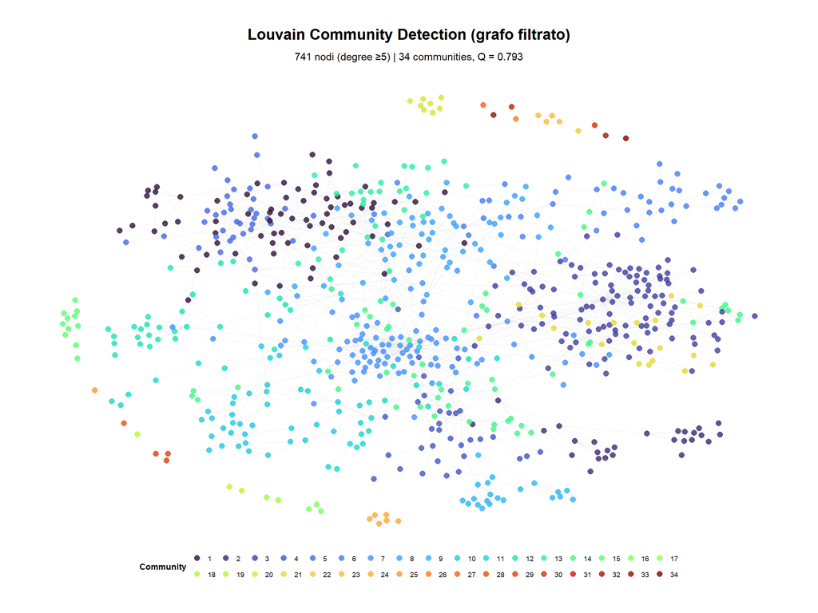

```r
# Plot 1

# Converto il sottografo in tidygraph
graph_tidy <- as_tbl_graph(graph_filtered) %>%
  mutate(community = as.factor(community))


# Layout
set.seed(42)

p <- ggraph(graph_tidy, layout = 'fr') +
  # Archi
  geom_edge_link(aes(),
                 color = "gray80",
                 width = 0.2,
                 alpha = 0.3) +
  # Nodi
  geom_node_point(aes(color = community),
                  size = 2.5,
                  alpha = 0.8) +
  # Tema e stile
  scale_color_viridis_d(option = "turbo", name = "Community") +
  labs(title = "Louvain Community Detection (grafo filtrato)",
       subtitle = paste0(vcount(graph_filtered), " nodi (degree ≥", min_degree, ") | ",
                        length(louvain_filtered), " communities, Q = ",
                        round(modularity(louvain_filtered), 3))) +
  theme_graph(base_family = "sans") +
  theme(legend.position = "bottom",
        legend.direction = "horizontal",
        legend.title = element_text(size = 9, face = "bold"),
        legend.text = element_text(size = 7),
        legend.key.size = unit(0.4, "cm"),
        legend.box.spacing = unit(0.1, "cm"),
        plot.title = element_text(size = 16, face = "bold", hjust = 0.5),
        plot.subtitle = element_text(size = 11, hjust = 0.5)) +
  guides(color = guide_legend(nrow = 2, byrow = TRUE))

print(p)
```

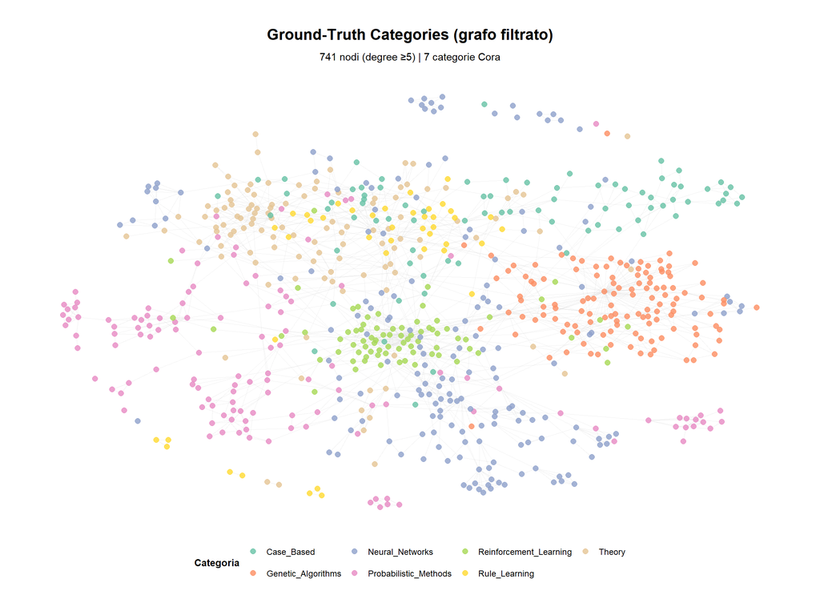

```r
# Plot 2
# Visualizzazione Ground-Truth (categorie)

# Converto il sottografo in tidygraph con categorie
graph_tidy_cat <- as_tbl_graph(graph_filtered) %>%
  mutate(category = as.factor(category))


# Stesso layout del primo grafico per confronto diretto
set.seed(42)

# Creo il plot con ggraph settando il colori in base alle categorie
p_cat <- ggraph(graph_tidy_cat, layout = 'fr') +
  geom_edge_link(aes(),
                 color = "gray80",
                 width = 0.2,
                 alpha = 0.3) +
  geom_node_point(aes(color = category),
                  size = 2.5,
                  alpha = 0.8) +
  scale_color_brewer(palette = "Set2", name = "Categoria") +
  labs(title = "Ground-Truth Categories (grafo filtrato)",
       subtitle = paste0(vcount(graph_filtered), " nodi (degree ≥", min_degree, ") | ",
                        length(unique(V(graph_filtered)$category)), " categorie Cora")) +
  theme_graph(base_family = "sans") +
  theme(legend.position = "bottom",
        legend.direction = "horizontal",
        legend.title = element_text(size = 10, face = "bold"),
        legend.text = element_text(size = 9),
        plot.title = element_text(size = 16, face = "bold", hjust = 0.5),
        plot.subtitle = element_text(size = 11, hjust = 0.5))

print(p_cat)
```

### Risposta a : Le communities coincidono con le categorie scientifiche ?

Abbiamo 7 Categorie vs 34 Communities trovate mediante Louvain

Cerchiamo di capire quale cattura meglio la struttura della rete.

L’idea è di eseguire il calcolo della modularity.

```r
# Estraggo i dati dal grafo
communities_best <- V(graph_filtered)$community  # Membership Louvain
categories <- V(graph_filtered)$category         # Categorie ground-truth


# Calcolo della modularity
modularity_res <- data.frame(
  K = integer(),
  Source = character(),
  Modularity = numeric(),
  Avg_size = numeric(),
  Min_size = integer(),
  Max_size = integer(),
  stringsAsFactors = FALSE
)
```

Ho qui 2 casi :

1. Ground-truth (7 categorie)
2. Louvain (communities già calcolate)

```r
# 1. Ground-truth

cat_membership <- as.numeric(factor(categories))
cat_communities <- make_clusters(graph_filtered, membership = cat_membership)
cat_modularity <- modularity(cat_communities)
cat_sizes <- table(cat_membership)

modularity_res <- rbind(modularity_res, data.frame(
  K = length(unique(cat_membership)),
  Source = "Ground-Truth (Categorie)",
  Modularity = round(cat_modularity, 4),
  Avg_size = round(mean(cat_sizes), 1),
  Min_size = min(cat_sizes),
  Max_size = max(cat_sizes)
))

# 2. Louvain

louv_communities <- make_clusters(graph_filtered, membership = communities_best)
louv_modularity <- modularity(louv_communities)
louv_sizes <- table(communities_best)

modularity_res <- rbind(modularity_res, data.frame(
  K = length(unique(communities_best)),
  Source = "Louvain (ottimale)",
  Modularity = round(louv_modularity, 4),
  Avg_size = round(mean(louv_sizes), 1),
  Min_size = min(louv_sizes),
  Max_size = max(louv_sizes)
))
```

Faccio infine un confronto.

```r
print(modularity_res, row.names = FALSE)
```

```
##   K                   Source Modularity Avg_size Min_size Max_size
##   7 Ground-Truth (Categorie)     0.6410    105.9       42      175
##  34       Louvain (ottimale)     0.7926     21.8        1      107
```

```r
mod_categories <- modularity_res$Modularity[1]
mod_louvain <- modularity_res$Modularity[2]
```

Le 7 categorie della Cora network risultano esser grossolane.

Louvain (k= 34) trova una struttura più modulare che cattura meglio le sotto comunità.

Modularity migliorata del 23.7 %

Mostro qui un plot comparativo.

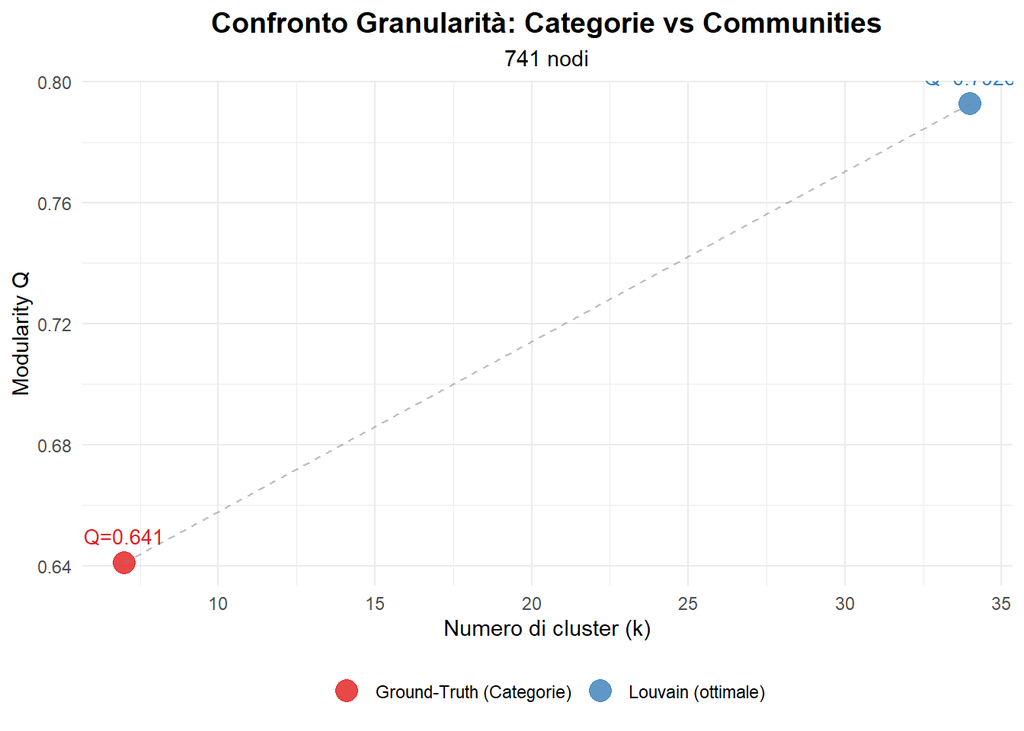

```r
p_granularity <- ggplot(modularity_res, aes(x = K, y = Modularity, color = Source)) +
  geom_point(size = 5, alpha = 0.8) +
  geom_line(aes(group = 1), linetype = "dashed", alpha = 0.5, color = "gray50") +
  geom_text(aes(label = paste0("Q=", Modularity)),
            vjust = -1.2, size = 3.5, show.legend = FALSE) +
  scale_color_brewer(palette = "Set1", name = NULL) +
  labs(title = "Confronto Granularità: Categorie vs Communities",
       subtitle = paste0(vcount(graph_filtered), " nodi"),
       x = "Numero di cluster (k)",
       y = "Modularity Q") +
  theme_minimal() +
  theme(legend.position = "bottom",
        plot.title = element_text(face = "bold", size = 14, hjust = 0.5),
        plot.subtitle = element_text(size = 11, hjust = 0.5))

print(p_granularity)
```

I risultati rivelano un disallineamento tra la categorizzazione scientifica nella Cora Nwteork e la struttura della rete (solo nodi con degree > 5):

1. **Ground-truth (k=7, Q=0.641)**:
- Le categorie scientifiche hanno una modularity moderata, la classificazione non cattura perfettamente i pattern di citazione.
2. **Louvain ottimale (k=34, Q=0.793)**:
- L’algoritmo converge a 34 communities, migliorando la modularity del 23.7%.
- Questo indica l’esistenza di sottocategorie tematiche** (es. CNN o RNN all’interno di Neural Networks).

Le 7 categorie sono macro-raggruppamenti grossolani. La struttura di citazione riflette specializzazioni più fini.

## Domanda 13 : Quali categorie sono più “pure” (una sola community o poche)?

Costruiamo una tabella di frammentazione e purezza per ciascuna categoria (ground-truth) nel grafo.

Lo facciamo incrociando la partizione fornita dall’algoritmo di community detection (Louvain) con la classificazione originale delle categorie.

Così da poter capire quanto le categorie sono “coese” o “frammentate” rispetto alle community trovate.

Costruiamo una tabella di frammentazione e purezza per ciascuna categoria incrociando la partizione Louvain con la classificazione originale.

```r
# Estraggo i dati
community_per_nodo <- V(graph_filtered)$community
categoria_per_nodo <- V(graph_filtered)$category
categories <- unique(categoria_per_nodo)

# Dataframe per metriche
fragplotdata <- data.frame(
  Category = character(),
  N_communities = integer(),
  Largest_pct = numeric(),
  stringsAsFactors = FALSE
)

# Dataframe per lo stacked bar plot
composition_data <- data.frame(
  Category = character(),
  Community = integer(),
  N_nodi = integer(),
  Percentuale = numeric(),
  stringsAsFactors = FALSE
)

# Per ogni categoria
for(cat in categories) {

  # Trovo i nodi di questa categoria
  nodes_in_cat <- which(categoria_per_nodo == cat)
  total_nodes <- length(nodes_in_cat)

  # Quali communities?
  communities_in_cat <- community_per_nodo[nodes_in_cat]

  # Distribuzione
  tab <- table(communities_in_cat)
  n_communities <- length(tab)

  # Calcolo delle metriche
  probs <- tab / sum(tab)
  distribution_pct <- 100 * probs

  # Purezza (% nella community dominante)
  largest_pct <- max(distribution_pct)

  # Salvo le metriche
  fragplotdata <- rbind(fragplotdata, data.frame(
    Category = cat,
    N_communities = n_communities,
    Largest_pct = largest_pct
  ))

  # Salvo composizione (per lo stacked bar plot)
  for (i in 1:length(tab)) {
    composition_data <- rbind(composition_data, data.frame(
      Category = cat,
      Community = as.integer(names(tab)[i]),
      N_nodi = as.integer(tab[i]),
      Percentuale = as.numeric(distribution_pct[i])
    ))
  }
}
```

Plot Composizione delle categorie e purezza.

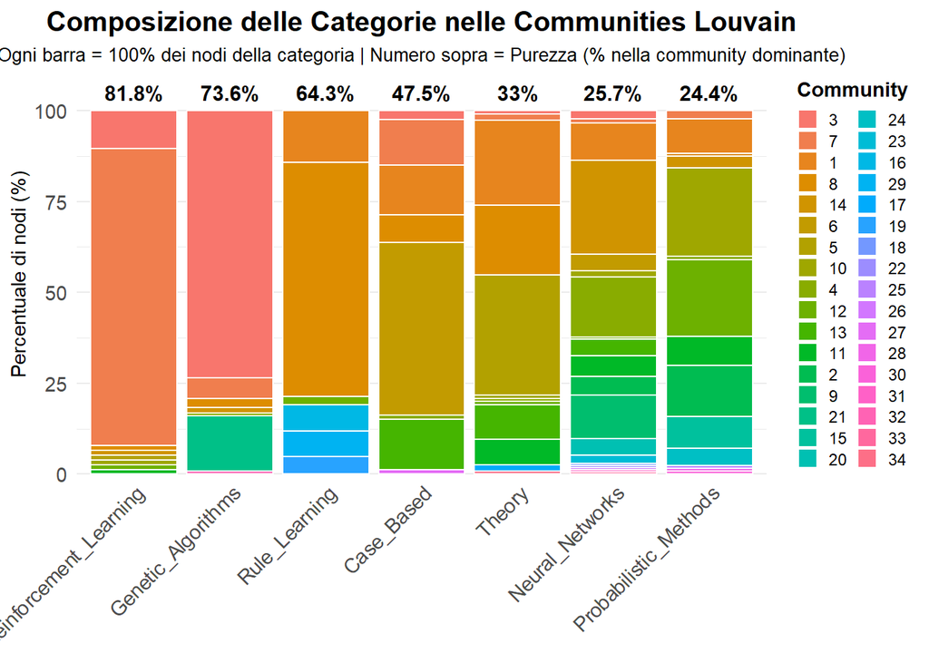

```r
# Ordino le categorie per purezza decrescente
category_order <- fragplotdata %>%
  arrange(desc(Largest_pct)) %>%
  pull(Category)

composition_data$Category <- factor(composition_data$Category, levels = category_order)

# Ordino poi communities per numero totale di nodi
community_importance <- composition_data %>%
  group_by(Community) %>%
  summarise(Total = sum(N_nodi)) %>%
  arrange(desc(Total))

composition_data$Community <- factor(composition_data$Community,
                                     levels = community_importance$Community)

# Plot 1 : Stacked bar chart

p_composition <- ggplot(composition_data, aes(x = Category, y = Percentuale, fill = Community)) +
  geom_bar(stat = "identity", color = "white", size = 0.3) +
  geom_text(data = fragplotdata %>% mutate(Category = factor(Category, levels = category_order)),
            aes(x = Category, y = 105, label = paste0(round(Largest_pct, 1), "%"), fill = NULL),
            size = 4, fontface = "bold", color = "black") +
  labs(title = "Composizione delle Categorie nelle Communities Louvain",
       subtitle = "Ogni barra = 100% dei nodi della categoria | Numero sopra = Purezza (% nella community dominante)",
       x = NULL,
       y = "Percentuale di nodi (%)",
       fill = "Community") +
  scale_y_continuous(expand = c(0, 0), limits = c(0, 110)) +
  theme_minimal() +
  theme(
    plot.title = element_text(face = "bold", hjust = 0.5, size = 15),
    plot.subtitle = element_text(hjust = 0.5, size = 10),
    axis.text.x = element_text(angle = 45, hjust = 1, size = 11),
    axis.text.y = element_text(size = 11),
    legend.position = "right",
    legend.title = element_text(size = 11, face = "bold"),
    legend.text = element_text(size = 9),
    panel.grid.major.x = element_blank()
  ) +
  guides(fill = guide_legend(ncol = 2, keywidth = 0.8, keyheight = 0.8))

print(p_composition)
```

Focus solo sulla purezza per categoria.

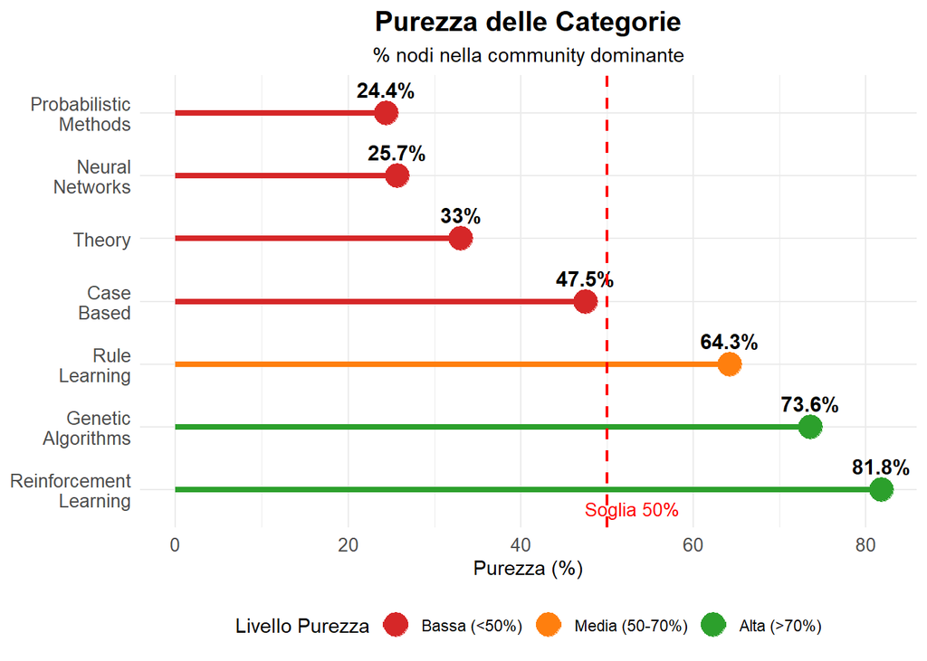

```r
# Plot 2 : Purezza (Lollipop chart)

frag_plot_data <- fragplotdata
frag_plot_data$Category_short <- gsub("_", "\n", frag_plot_data$Category)

frag_plot_data <- frag_plot_data[order(-frag_plot_data$Largest_pct), ]
frag_plot_data$Category_short <- factor(frag_plot_data$Category_short,
                                        levels = frag_plot_data$Category_short)

frag_plot_data$Purezza_level <- cut(frag_plot_data$Largest_pct,
                                    breaks = c(0, 50, 70, 100),
                                    labels = c("Bassa (<50%)",
                                               "Media (50-70%)",
                                               "Alta (>70%)"))

p2 <- ggplot(frag_plot_data, aes(x = Category_short, y = Largest_pct,
                                 color = Purezza_level)) +
  geom_segment(aes(xend = Category_short, y = 0, yend = Largest_pct),
               linewidth = 1.5) +
  geom_point(size = 6) +
  geom_text(aes(label = paste0(round(Largest_pct, 1), "%")),
            vjust = -1, size = 4, color = "black", fontface = "bold") +
  geom_hline(yintercept = 50, linetype = "dashed", color = "red", linewidth = 0.8) +
  annotate("text", x = 0.7, y = 53, label = "Soglia 50%",
           color = "red", size = 3.5) +
  scale_color_manual(values = c("Bassa (<50%)" = "#d62728",
                                "Media (50-70%)" = "#ff7f0e",
                                "Alta (>70%)" = "#2ca02c"),
                     name = "Livello Purezza") +
  coord_flip() +
  labs(title = "Purezza delle Categorie",
       subtitle = "% nodi nella community dominante",
       x = NULL, y = "Purezza (%)") +
  theme_minimal() +
  theme(plot.title = element_text(face = "bold", hjust = 0.5, size = 15),
        plot.subtitle = element_text(hjust = 0.5, size = 11),
        legend.position = "bottom",
        axis.text = element_text(size = 10))

print(p2)
```

Tutte le categorie sono frammentate.

Prendiamo ad esempio Neural Networks (la 2^a più frammentata):

- La mia idea è che non esista un unico argomento “Neural Networks” unificato, ma si divida ulteriormente in CNN, RNN, GAN, Transformers, etc.

Reinforcement Learning (MENO frammentata):

- 81.8% dei nodi in una sola community (7)
- Ma comunque divisa in 8 communities → ancora frammentata

## Domanda 14 : Studia i K-connected components e verifica se i gruppi con connettività più alta sono composti da soli paper di una stessa catgoria.

Creo una copia del grafo e la converto in non diretto.

Nota che qui per ora non restringiamo la rete rispetto a qulla orginale (come avevo fatto prima con graph_filtered). Lo faremo però tra poco.

```r
graph_undirected <- as_undirected(graph, mode = "collapse")

cat("Grafo convertito:\n")
```

```
## Grafo convertito:
```

```r
cat("  Nodi:", vcount(graph_undirected), "\n")
```

```
##   Nodi: 2708
```

```r
cat("  Archi:", ecount(graph_undirected), "\n")
```

```
##   Archi: 5278
```

```r
cat("  Densità:", round(ecount(graph_undirected) / (vcount(graph_undirected) * (vcount(graph_undirected) - 1) / 2), 4), "\n")
```

```
##   Densità: 0.0014
```

```r
cat("  Diretto:", is_directed(graph_undirected), "\n\n")
```

```
##   Diretto: FALSE
```

### Connected Component

La componente connessa di un grafo non diretto è il set massimo di nodi tale che ogni coppia di nodi è connessa da un path.

Il Giant Component riempie la maggior parte della rete.

Per poter ottenere tale Connected Component, ho creato una copia del grafo ma indiretto.

Lavoro qui con il grafo indiretto.

```r
# Trovo le componenti connesse
cc <- components(graph_undirected)

cat("Numero componenti connesse:", cc$no, "\n")
```

```
## Numero componenti connesse: 78
```

```r
cat("Giant Component:", max(cc$csize), "nodi\n")
```

```
## Giant Component: 2485 nodi
```

```r
cat("Percentuale della Giant Component:", round(100 * max(cc$csize) / vcount(graph_undirected), 1), "%\n")
```

```
## Percentuale della Giant Component: 91.8 %
```

```r
# Nodi che sono nella componente gigante
gc_nodes <- which(cc$membership == which.max(cc$csize))

gc_subgraph <- induced_subgraph(graph_undirected, gc_nodes)
```

### K-Connected Components

Adesso, come fatto prima, filtriamo per tenere solo i nodi con un grado >= 5 (perchè ho un grafo non diretto).

```r
# Connettività del grafo
#vertex_connectivity(gc_subgraph)

# Calcolo il grado
deg_gc <- degree(gc_subgraph)

# Filtro i nodi, tengo soli quelli con grado >= 5
keep_nodes <- which(deg_gc >= 5)
g_filtered <- induced_subgraph(gc_subgraph, keep_nodes)

# Quanti nodi rimangono
# vcount(g_filtered)

# Quanti archi rimangono
#ecount(g_filtered)

# Calcolo i cohesive blocks su questo grafo ridotto
b <- cohesive_blocks(g_filtered)
print(b)
```

```
## Cohesive block structure:
## B-1                c 0, n 686
## '- B-2             c 1, n 664
##    '- B-5          c 4, n   6
##    '- B-6          c 3, n   9
##       '- B-17      c 4, n   8
##    '- B-7          c 2, n   3
##    '- B-8          c 2, n   7
##       '- B-18      c 3, n   6
##    '- B-9          c 2, n   4
##    '- B-10         c 2, n   3
##    '- B-11         c 3, n   5
##    '- B-12         c 3, n   5
##    '- B-13         c 2, n   3
##    '- B-14         c 2, n   4
##    '- B-16         c 2, n 571
##       '- B-19      c 4, n   6
##       '- B-20      c 3, n  12
##          '- B-24   c 4, n   6
##       '- B-21      c 3, n   4
##       '- B-22      c 3, n   7
##       '- B-23      c 3, n   4
##       '- B-25      c 3, n   4
##       '- B-26      c 3, n   4
##       '- B-27      c 3, n  15
##       '- B-28      c 3, n  16
##       '- B-29      c 3, n 310
##          '- B-31   c 4, n   8
##          '- B-32   c 4, n   5
##          '- B-33   c 4, n  22
##       '- B-30      c 3, n   6
## '- B-3             c 2, n   7
##    '- B-15         c 3, n   6
## '- B-4             c 2, n   4
```

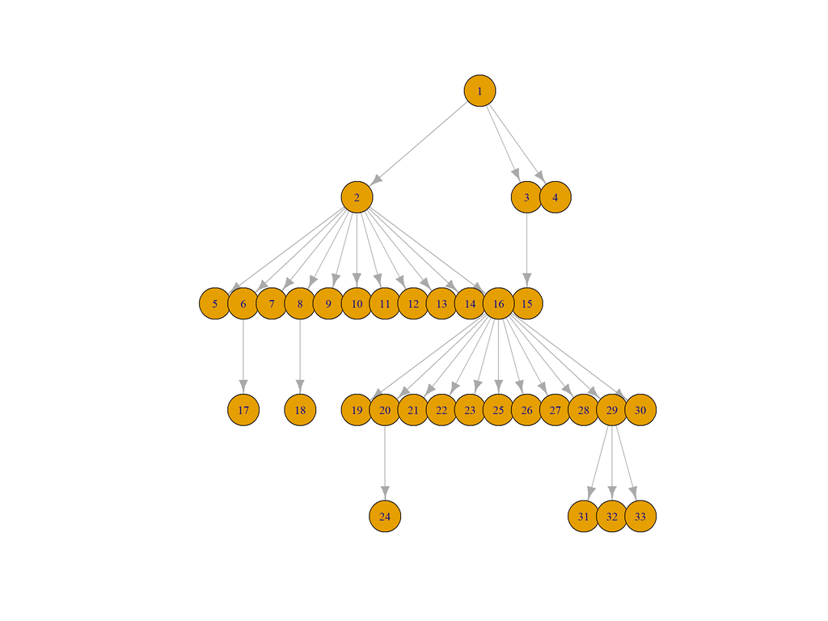

```r
plot_hierarchy(b)
```

La struttura dei cohesive blocks è fatta da 33 blocchi, con alcuni che hanno una connettività pari a massimo 4.

Mi concentro su questi blocchi.

```r
# Nodi dai blocchi
bn = blocks(b)

# Creo una lista in cui metto 1 grafo per ciascun blocco, esso conterrà solo i nodi e gli archi relativi a quel blocco
bg = graphs_from_cohesive_blocks(b, g_filtered)

# Ottengo la coesione di ogni blocco
coe = cohesion(b)

# Trovo i blocchi con coesione massima
max_coe <- max(coe)
idx_max <- which(coe == max_coe)

categories <- sort(unique(V(g_filtered)$category))
n_cat <- length(categories)
```

Plotto ogni blocco con coesione massima

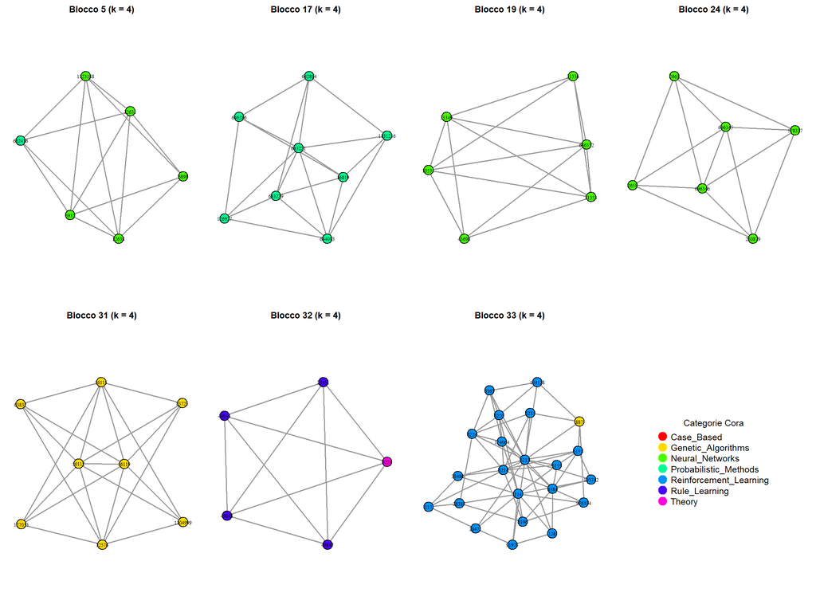

```r
# Rainbow
cat_colors <- rainbow(n_cat)
names(cat_colors) <- categories

# Plotto ogni blocco con coesione massima
par(mfrow = c(2, 4), mar = c(1, 1, 2, 1))  # 2 righe, 4 colonne per 7 grafici

for (i in seq_along(idx_max)) {
  h <- bg[[ idx_max[i] ]]

  # Assegno i colori in base alla categoria
  V(h)$color <- cat_colors[ V(h)$category ]

  plot(
    h,
    vertex.size = 12,
    vertex.label = V(h)$name,
    vertex.label.cex = 0.7,
    vertex.label.color = "black",
    vertex.frame.color = "black",
    edge.color = "grey60",
    edge.width = 1.5,
    layout = layout_with_fr(h),
    main = paste0("Blocco ", idx_max[i], " (k = ", max_coe, ")")
  )
}

# Aggiungo la legenda
plot.new()
legend(
  "center",
  legend = categories,
  col = cat_colors,
  pch = 19,
  pt.cex = 2.5,
  cex = 1.2,
  title = "Categorie Cora",
  bty = "n"
)
```

Quello mostrato è il core più robusto della rete di citazione.

L’analisi si è dimostrata interessante nei blocchi 5, 32 e 33. Infatti al suo interno troviamo dei paper outsider, ossia con una categoria diversa da quella di tutti gli altri.

Provo a proseguire con questa analisi, andando a mostrare i blocchi con coesione max - 1.

```r
# Voglio ora solo i blocchi con coesione = max - 1
target_coe <- max_coe - 1
idx_target <- which(coe == target_coe)

cat("Blocchi con coesione k =", target_coe, ":\n")
```

```
## Blocchi con coesione k = 3 :
```

```r
print(idx_target)
```

```
##  [1]  6 11 12 15 18 20 21 22 23 25 26 27 28 29 30
```

```r
cat("Numero di blocchi:", length(idx_target), "\n\n")
```

```
## Numero di blocchi: 15
```

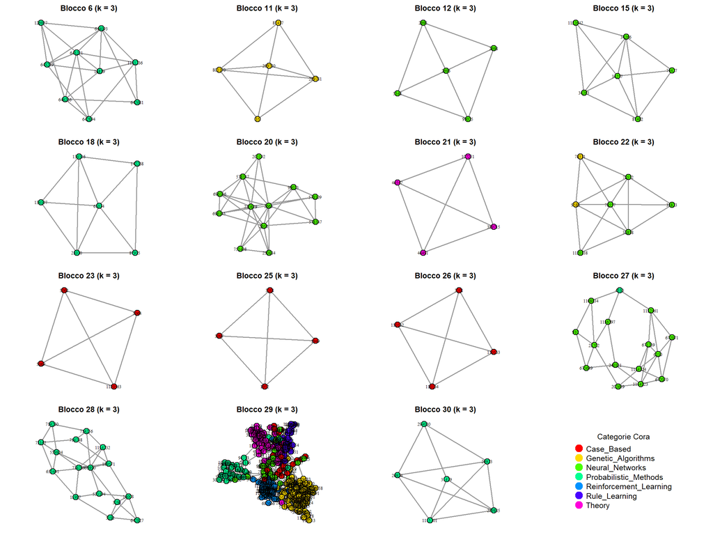

```r
# Calcolo il numero di righe e colonne per il layout
n_plots <- length(idx_target) + 1
n_cols <- 4
n_rows <- ceiling(n_plots / n_cols)

# Plotto ogni blocco con coesione
par(mfrow = c(n_rows, n_cols), mar = c(1, 1, 2, 1))

for (i in seq_along(idx_target)) {
  h <- bg[[ idx_target[i] ]]

  V(h)$color <- cat_colors[ V(h)$category ]

  plot(
    h,
    vertex.size = 12,
    vertex.label = V(h)$name,
    vertex.label.cex = 0.7,
    vertex.label.color = "black",
    vertex.frame.color = "black",
    edge.color = "grey60",
    edge.width = 1.5,
    layout = layout_with_fr(h),
    main = paste0("Blocco ", idx_target[i], " (k = ", target_coe, ")")
  )
}

# Legenda
plot.new()
legend(
  "center",
  legend = categories,
  col = cat_colors,
  pch = 19,
  pt.cex = 2.5,
  cex = 1.2,
  title = "Categorie Cora",
  bty = "n"
)
```

Analizziamo il blocco 29 più in dettaglio.

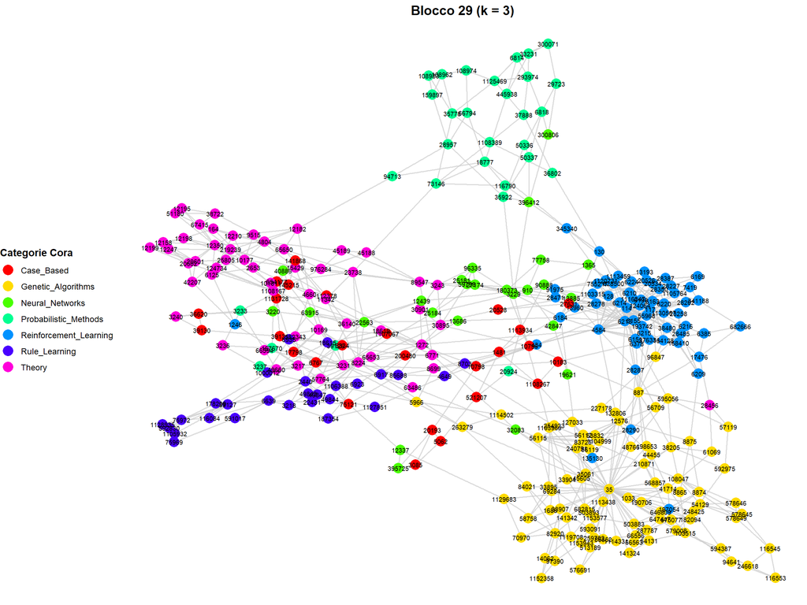

```r
bloc_id <- 29                 # ID del blocco
k_bloc  <- coe[bloc_id]       # livello di coesione del blocco

# Prendo il sottografo del blocco
h_bloc <- bg[[bloc_id]]

# Converto in tbl_graph per ggraph
h_tbl <- as_tbl_graph(h_bloc)


ggraph(h_tbl, layout = "fr") +
  geom_edge_link(colour = "grey80", width = 0.6, alpha = 0.7) +
  geom_node_point(aes(color = category), size = 5) +
  geom_node_text(
    aes(label = name),
    color = "black",
    size  = 2.4
  ) +
  scale_color_manual(values = cat_colors, name = "Categorie Cora") +
  ggtitle(paste0("Blocco ", bloc_id, " (k = ", k_bloc, ")")) +
  theme_void() +
  theme(
    plot.title      = element_text(hjust = 0.5, face = "bold", size = 14),
    legend.position = "left",
    legend.title    = element_text(size = 11, face = "bold"),
    legend.text     = element_text(size = 9)
  )
```

La categoria Neural_Networks risulta esser più dispersa rispetto alle altre categorie. Ciò è causato da una maggioranza delle connessioni verso le altre categorie, piuttosto che intra-categoria.

Inoltre ho che Reinforcement_Learning risulta esser denso ma allo stesso tempo importante per varie altre categorie.

## Domanda 15 : Analizza gli SCC per verificare l’aciclicità della rete.

### Strongly Connected Components

Nel caso di un grafo diretto, abbiamo questa nozione.

2 nodi sono nello stesso Strongly Connected Components se sono a vicendnda raggiungibili mediante un directed path.

Formano una partizione del set dei vertici e definiscono una relazione di equivalenza tra nodi.

In questo caso stiamo lavorando con una citation network, la quale è una quasi aciclica.

Questo è dovuto al fatto che quando un paper ne cita un altro, questo citato sarà stato per forza scritto in passato (e dunque non può ricambiare la connssione)

Dunque poichè la Cora citation network è quasi aciclica, mi aspetto di non trovare SCC di grandi dimensioni.

```r
scc <- components(graph, mode = "strong")

cat("Numero Strongly Connected Components:", scc$no, "\n")
```

```
## Numero Strongly Connected Components: 2526
```

```r
cat("Taglia massima SCC:", max(scc$csize), "\n")
```

```
## Taglia massima SCC: 13
```

```r
nodes_scc = which(scc$membership == which.max(scc$csize))



# Tabella distribuzione SCC per dimensione
scc_distribution <- table(scc$csize)
scc_df <- data.frame(
  Dimensione = as.numeric(names(scc_distribution)),
  Numero_SCC = as.numeric(scc_distribution)
)

# Ordina per dimensione
scc_df <- scc_df %>% arrange(desc(Dimensione))

# Distribuzione SCC per dimensione
print(scc_df)
```

```
##   Dimensione Numero_SCC
## 1         13          1
## 2          7          1
## 3          6          1
## 4          5          4
## 5          4          5
## 6          3         18
## 7          2         92
## 8          1       2404
```

Ho dunque un elevatissimo numero di SCC, proprio come previsto.

Inoltre è possibile osservare la distribuzione delle dimensioni degli SCC.

Quasi tutti gli SCC hanno 1 solo elemento.

Mostro ora la tabella dell’ SCC massimo ordinata per PageRank decrescente.

```r
# Crea tabella con informazioni sui nodi della SCC massima
scc_table <- data.frame(
  node_id = V(graph)[nodes_scc]$name,
  category = V(graph)[nodes_scc]$category,
  pagerank = round(V(graph)[nodes_scc]$pagerank * 100, 3),
  betweenness = round(V(graph)[nodes_scc]$betweenness, 2)
)

# Ordina per PageRank decrescente
scc_table <- scc_table %>% arrange(desc(pagerank))

print(scc_table)
```

```
##       node_id              category pagerank betweenness
## 10435   10435            Case_Based    0.039     1045.00
## 13686   13686       Neural_Networks    0.035     8970.50
## 22566   22566            Case_Based    0.032        0.00
## 8703     8703         Rule_Learning    0.031     2218.83
## 1272     1272                Theory    0.027     9523.50
## 27535   27535 Probabilistic_Methods    0.026     2547.33
## 51866   51866                Theory    0.025      437.50
## 8224     8224                Theory    0.023     6908.33
## 22563   22563       Neural_Networks    0.023     3969.25
## 23738   23738                Theory    0.022     1774.92
## 85688   85688         Rule_Learning    0.020     7271.00
## 36140   36140                Theory    0.020      455.33
## 22564   22564            Case_Based    0.020        0.00
```

Lavoro ora con il sottografo della SCC massima.

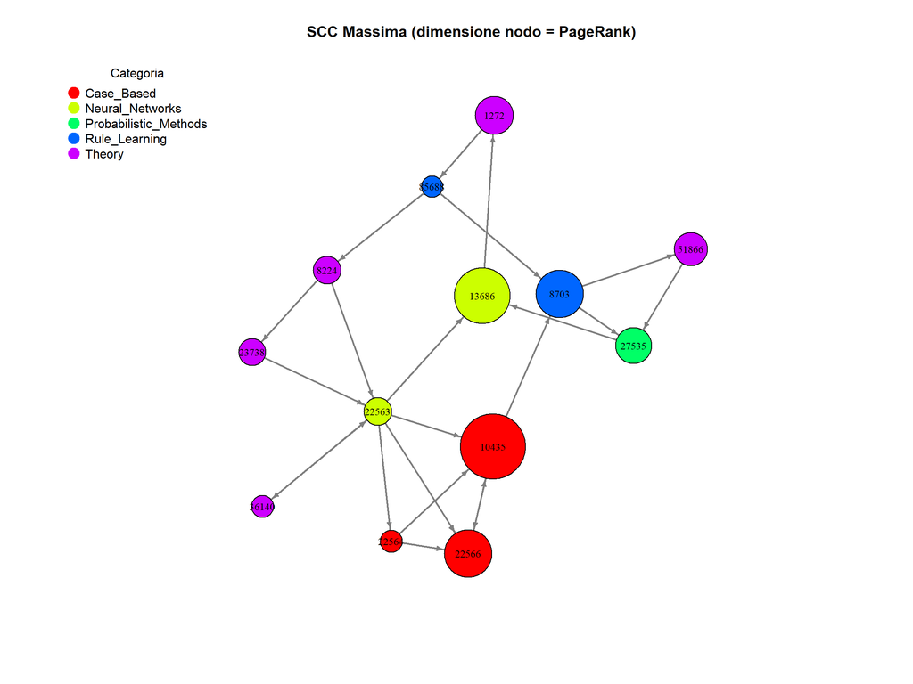

```r
# Prendo il sottografo della SCC massima
g_scc <- induced_subgraph(graph, nodes_scc)

# Palette di colori per categorie
categories <- sort(unique(V(g_scc)$category))
cat_colors <- rainbow(length(categories))
names(cat_colors) <- categories

V(g_scc)$color <- cat_colors[V(g_scc)$category]

# Scala la dimensione dei nodi in base al PageRank
pagerank_vals <- V(g_scc)$pagerank
vertex_sizes <- scales::rescale(pagerank_vals, to = c(10, 30))

# Plot del sottografo SCC massima

plot(
  g_scc,
  vertex.size = vertex_sizes,
  vertex.label = V(g_scc)$name,
  vertex.label.cex = 0.8,
  vertex.label.color = "black",
  vertex.frame.color = "black",
  edge.arrow.size = 0.5,
  edge.color = "grey50",
  edge.width = 2,
  layout = layout_with_kk(g_scc),
  main = "SCC Massima (dimensione nodo = PageRank)"
)

# Legenda
legend(
  "topleft",
  legend = categories,
  col = cat_colors,
  pch = 19,
  pt.cex = 2,
  bty = "n",
  title = "Categoria"
)
```

Notare come in questo SCC ci siano dei paper che si citano a vicenda, il che risulta controintuitivo in una citation network.

## Domanda 16 : Verifica lo Small-World Effect sul grafo non diretto.

Lo Shortest Path tra 2 nodi (Geodesic Path) in un grafo è il path con il numero minore di edges.

La lunghezza di tale path è detta Shortest Distance (Geodesic Distance).

Lo Small-World effect mi dice che la Shortest Distance è tipicamente sorprendentemente corta.

Uso qui il grafo non diretto ottenuto in precedenza.

```r
# Distanza media tra i nodi (gradi di separazione)
avg_dist <- mean_distance(graph_undirected)
cat("Distanza media (gradi di separazione):", round(avg_dist, 2), "\n")
```

```
## Distanza media (gradi di separazione): 6.31
```

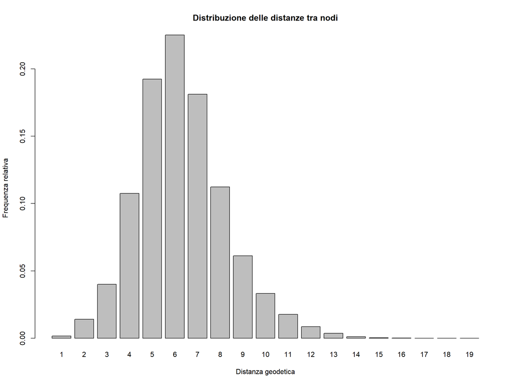

```r
# Tabella delle distanze geodetiche
dist_table <- distance_table(graph_undirected)

# Istogramma/frequenza delle distanze
paths <- dist_table$res
names(paths) <- as.character(1:length(paths))
barplot(
  paths / sum(paths),
  xlab = "Distanza geodetica",
  ylab = "Frequenza relativa",
  main = "Distribuzione delle distanze tra nodi"
)
```

In questo caso lo Small-World Effect mostra di rispettare la teoria dei 6 gradi di separazione.

## Domanda 17 : Verifica che la Assortativity by category sia molto alta (dato che ho tante citazioni intra-categoria)

Le persone preferiscono stare con altri che sono in qualche modo simili a loro (Homophily).

Ogni nodo della rete può essere assegnato ad un tipo in base al valore della caratteristica per quel nodo.

La rete è Assortative se una frazione significante delle edges corre tra vertici dello stesso tipo.

La Modularity è una misura della Assortativity di una rete.

Posso normalizzare la Modularità andando a dividere per il massimo valore che essa può assumere.

Una misura dell’ assortative mixing in base ad una caratteristica scalare è la Covarianza.

L’Assortativity Coefficient è la misura della normalized assortativity, definita come il Coefficiente di correlazione di Pearson.

Essa misura quanto i paper della stessa categoria tendono a collegarsi tra loro.

```r
assortativity_category <- assortativity_nominal(graph_undirected, as.factor(V(graph_undirected)$category), directed = FALSE)
cat("Assortativity by category:", assortativity_category, "\n")
```

```
## Assortativity by category: 0.7710854
```

(0.77): Fortissima omofilia di categoria: le citazioni avvengono molto spesso tra nodi della stessa categoria.

Ma questo era facil intuirlo fin dall’inizio.

## Domanda 18 : Verifica se l’elite delle pubblicazioni crea un “club” chiuso

In pratica se i paper (nodi) ad alta centralità (PageRank) tendono a citare/ricevere citazioni da altri paper ugualmente centrali, o la rete di influenze è più sparsa.

Se l’assortatività è positiva, allora l’elite dei paper centrali cita prevalentemente altri paper influenti, creando una sorta di “elite club” della rete della conoscenza scientifica.

```r
pr <- page_rank(graph_undirected)$vector
edge <- as_edgelist(graph_undirected, names = FALSE)
l <- c(edge[,1], edge[,2])
r <- c(edge[,2], edge[,1])
pl <- pr[l]
prr <- pr[r]
assortativity_pagerank <- cor(pl, prr)
cat("Assortatività rispetto al PageRank:", assortativity_pagerank, "\n")
```

```
## Assortatività rispetto al PageRank: -0.07957071
```

Non si forma un “elite club”.

I paper centrali non creano una sottorete chiusa e autoreferenziale, ma sono piuttosto ponte verso molti altri paper meno centrali.

Il valore è vicino a zero, quindi si tratta di una tendenza debole.